# esKnow_ManuscriptAnalysis

Karen Sasmita

2024-02-23

This markdown analyses and plots results from study; esKnow 1 and esKnow 2. Project description: - esKnow1: 2grain (coarse & fine) x 2movie(3Iron and Corn) x 3condition(Uninterrupted, Interrupted, Jumbled) within-within-between subjects segmentation task followed by untimed free recall (type in to document). - esKnow2: 2grain(coarse & fine) x 2movies(3Iron and Corn) x 3conditions(Uninterrupted, Interrupted, Jumbled) between-within-between subjects segmentation task followed by 5 minute free recall (recall then type in one remembered event at a time)

Segmentation task stimuli: - Movies are ~10 minute long, no audio, 2 main characters in each movie performing identifiable everyday actions (e.g., doing laundry, sawing wood) - Participants in the Interrupted and Jumbled conditions segmented the movies presented in clips (esKnow1: 1min, esKnow2: 5sec) with interruptions in between clips (esKnow1: 3sec, esKnow2: .5sec). Clips (other than the first and last clips) were presented out of order in Jumbled condition.

Question: How on and on what timescale do people accumulate real-time information for event segmentation? - Does information need to be accumulated continuously (Interruption & Jumbled should affect segmentation/ memory) - Or does it need to be accumulated coherently over time? (Jumbled should have effect on segmentation/ memory) Event segmentation and memory have been tightly linked: segmentation defines the event unit stored in memory. Do these two processes (segmentation & memory) rely on information accummulated on the same timescale? - Would any impairment in segmentation due to disruptions in information flow (Interrupted/ Jumbled) be similarly reflected in memory performance?

**Load libraries**

```r
rm(list = ls())
currDir = getwd()

library(dplyr)
library(ggplot2)
library(emmeans)
library(lme4)
library(tidyr)
library(foreach)
library(ggsignif)
library(corrplot)
library(tidyverse)
library(ggcorrplot)
library(lsr)
library(ggpubr)
library(patchwork)
library(scales)
library(cowplot)
library(pdftools)
library(effectsize)
library(drc)
library(Mediana)
library(ggchicklet) #to make rounded rectangles in ggplot
library(ggdendro)
library(rstan)
library(rstanarm)
library(BayesFactor)
#library(DescTools)
source("get.agreement.metrices.R")
```

**Setup plot theme**

```r
#Set text size and colors
txt.size = 14
txt.color = "black"
txt.face = "bold"
txt.font = "Arial"

#Define colors
colors <- data.frame(point.colors = c('#268072','#F37C2D','#F9C047', "#91b8af", "#fcb78f", "#f6e8d5"), label = c('u.color', 'i.color', 'j.color', 'u2.color', 'i2.color', 'j2.color'))
jitter.outline = "#f1f1f1"
outline.color = "#41424c"
legend.color = "#51535c"
legend2.color = "#9d9ea3"

#jitter for individual agreement values
jitter.alpha = .7
jitter.width = 0.3
jitter.size = 2

#point for mean agreement value
point.size = 5
point.alpha = 1
point.stroke = 1.4
point.shape = 21
#errorbar width
errorbar.width = .3
errorbar.alpha = 1
errorbar.size = 1.2

grain.labs <- c("Coarse", "Fine")
names(grain.labs) <- c("c", "f")

#Set theme for plotting
theme.esKnow <- theme(
  panel.grid.minor = element_blank(),
  panel.grid.major = element_blank(),
  #panel.background= element_blank(),
  panel.border = element_blank(),
  panel.spacing = unit(.05,'in'),
  panel.background = element_rect(fill = "transparent",colour = NA),
  plot.background = element_rect(fill = "transparent",colour = NA),
  axis.line = element_line(size = 0.5, colour = outline.color),
  axis.title = element_text(size = txt.size, family = txt.font, color = txt.color, face = txt.face),
  axis.text = element_text(size = txt.size, family = txt.font, color = txt.color, face = txt.face),
  axis.title.y = element_text(margin = margin(t = 0, r = 10, b = 0, l = 0)),
  axis.title.x = element_text(margin = margin(t = 10, r = 0, b = 0, l = 0)),
  strip.background = element_rect(colour = NA, fill = "transparent"),
  strip.text = element_text(size = txt.size, family = txt.font, color = txt.color, face = txt.face),
  legend.title = element_blank(),
  legend.key = element_rect(colour = NA, fill = NA),
  plot.title = element_text(hjust = 0.5,size = txt.size, family = txt.font, color = txt.color, face = txt.face)
)
```

# Load things

**Load data and utils**

```r
setwd('../data/')

#file containing start time, end time and index of fine and coarse events (based on normative boundary and used to determine recall coding)
esKnow.eventTimeIndex <- read.csv('esKnow_eventTimeIndex.csv', head = TRUE)

#segmentation data
esKnow1.segmentdata <- read.delim('esKnow_segmentdata.txt', head = TRUE)
esKnow2.segmentdata <- read.delim('esKnow2_segmentdata.txt', head = TRUE)

#recall data
esKnow1.lagCRP <- read.csv('esKnow_lagCRP_separated.csv', head = TRUE)
esKnow1.precision <- read.csv('esKnow_precision.csv', head = TRUE)
esKnow1.recall <- read.csv('esKnow_recallScores.csv', head = TRUE)
esKnow1.clustering <- read.csv('esKnow_clustering_separated.csv', head = TRUE)
```

Check that participants adhered to the supposed 15-36 button press for practice in esKnow2.

```r
esKnow2.prac.bp <- esKnow2.segmentdata[esKnow2.segmentdata$movName == "prac",]

#assign practice index
assign.bpRound <- function(ts){
    idx = which(diff(ts) < 0)
  if(length(idx) == 0){
    pracRound = rep(1, length(ts))
  }else{
    idx = c(0, idx,length(ts))
    pracRound = rep(0, length(ts))
    for(i in seq(from = 1, to = length(idx)-1)){
      pracRound[seq(from = idx[i]+1, to = idx[i+1], by = 1)] = i
    }
  }
    return(pracRound)
}
esKnow2.prac.bps <- data.frame()
for(sub in unique(esKnow2.prac.bp$subid)){
  dat <- esKnow2.prac.bp[esKnow2.prac.bp$subid == sub,]
  dat$pracRound <- unlist(tapply(dat$bpTime.series, dat$subid, assign.bpRound))
  esKnow2.prac.bps<- rbind(esKnow2.prac.bps, dat)
}

esKnow2.prac.bp$pracRound <- unlist(tapply(esKnow2.prac.bps$bpTime.series, esKnow2.prac.bps$subid, assign.bpRound))
```

Select data for esKnow2 segmentation and rename movie to match movie naming of esKnow1

```r
esKnow2.segmentdata <- esKnow2.segmentdata[esKnow2.segmentdata$movName != 'prac',] #exclude practice data

esKnow2.segmentdata$movName <- unlist(lapply(esKnow2.segmentdata$movName, function(x){
  if(x == 'iron'){
    return("3Iron")
  } else {
    return("Corn")
  }
}))
```

Define factors and levels

```r
grain.factor = c("c", "f")
condition.factor = c("Uninterrupted", "Interrupted", "Jumbled")
movie.factor = c("3Iron", "Corn")

##reorder factors
#segmentation data
esKnow1.segmentdata$grain <- factor(esKnow1.segmentdata$grain, levels = grain.factor)
esKnow1.segmentdata$condition <- factor(esKnow1.segmentdata$condition, levels = condition.factor)
esKnow1.segmentdata$movName <- factor(esKnow1.segmentdata$movName, levels = movie.factor)
esKnow1.segmentdata$grainorder <- factor(esKnow1.segmentdata$grainorder, levels = c(1,2)) #whether the segmentation data is from the 1st or 2nd round of segmentation

esKnow2.segmentdata$grain <- factor(esKnow2.segmentdata$grain, levels = grain.factor)
esKnow2.segmentdata$condition <- factor(esKnow2.segmentdata$condition, levels = condition.factor)
esKnow2.segmentdata$movName <- factor(esKnow2.segmentdata$movName, levels = movie.factor)

#recall data
esKnow1.clustering$condition <- factor(esKnow1.clustering$condition, levels = condition.factor)
esKnow1.clustering$movName <- factor(esKnow1.clustering$movName, levels = movie.factor)

esKnow1.lagCRP$condition <- factor(esKnow1.lagCRP$condition, levels = condition.factor)
esKnow1.lagCRP$movName <- factor(esKnow1.lagCRP$movName, levels = movie.factor)

esKnow1.precision$condition <- factor(esKnow1.precision$condition, levels = condition.factor)
esKnow1.precision$movName <- factor(esKnow1.precision$movName, levels = movie.factor)

esKnow1.recall$condition <- factor(esKnow1.recall$condition, levels = condition.factor)
esKnow1.recall$movName <- factor(esKnow1.recall$movName, levels = movie.factor)
```

Define some varible constants to use in analyses later on.

```r
#movie duration
iron.mov.dur = 589 #seconds
corn.mov.dur = 566 #seconds

#for density estimations
bw = 'SJ'
c.adj = 0.1
f.adj = 0.05
dens.hz = 1

#for timeseries
bin.size = 1 #seconds

#for spectral density estimation
spect.adj = .01 #need to be low enough to pick up variation in segmentation pattern over time
del = 1
bw = 'SJ'

#to divide segmentation data per clip into n segments
esKnow1.nsegment <- 12 #divide each 1 minute clip to segments of 5s intervals
esKnow2.nsegment <- 5 #divide each 5 second clip to segments of 1s intervals

#list of separated fine event number (only applicable for esKnow1)
iron_separated <- c(10, 22, 30, 38, 43, 50, 58, 62, 67)
corn_separated <- c(7, 14, 21, 30, 37, 45, 52, 59, 65)

#total number of event units coded in recall
nEvents_iron_fine <- 74
nEvents_corn_fine <- 69

nEvents_iron_coarse <- 25
nEvents_corn_coarse <- 22
```

# Inspect data

## Experiment 1

```r
head(esKnow1.segmentdata)
```

```
##   subid phase movieOrder       movieName grain movieStartTime keypressed
## 1     2     1          1 3Iron_10Min.mp4     c         5.2804      space
## 2     2     1          1 3Iron_10Min.mp4     c         5.2804      space
## 3     2     1          1 3Iron_10Min.mp4     c         5.2804      space
## 4     2     1          1 3Iron_10Min.mp4     c         5.2804      space
## 5     2     1          1 3Iron_10Min.mp4     c         5.2804      space
## 6     2     1          1 3Iron_10Min.mp4     c         5.2804      space
##    bpTime movieDuration     condition clipNo movName bpTime.series
## 1 18.0786            NA Uninterrupted      1   3Iron       18.0786
## 2 40.5017            NA Uninterrupted      1   3Iron       40.5017
## 3 10.6353            NA Uninterrupted      2   3Iron       70.6953
## 4 20.5516            NA Uninterrupted      2   3Iron       80.6116
## 5 34.5999            NA Uninterrupted      2   3Iron       94.6599
## 6 57.4187            NA Uninterrupted      2   3Iron      117.4787
##   totalMovieDur grainorder include
## 1      589.3222          2       1
## 2      589.3222          2       1
## 3      589.3222          2       1
## 4      589.3222          2       1
## 5      589.3222          2       1
## 6      589.3222          2       1
```

```r
summary(esKnow1.segmentdata)
```

```
##      subid            phase     movieOrder    movieName         grain
##  Min.   :  1.00   Min.   :1   Min.   :1.00   Length:19876       c: 4994
##  1st Qu.:  8.00   1st Qu.:1   1st Qu.:1.00   Class :character   f:14882
##  Median : 15.00   Median :1   Median :1.00   Mode  :character
##  Mean   : 17.26   Mean   :1   Mean   :1.48
##  3rd Qu.: 25.00   3rd Qu.:1   3rd Qu.:2.00
##  Max.   :141.00   Max.   :1   Max.   :2.00
##
##  movieStartTime      keypressed            bpTime        movieDuration
##  Min.   : 0.03365   Length:19876       Min.   : 0.0034   Min.   :47.11
##  1st Qu.: 0.04509   Class :character   1st Qu.:13.9352   1st Qu.:60.09
##  Median : 0.06723   Mode  :character   Median :29.3570   Median :60.19
##  Mean   : 0.80770                      Mean   :29.3103   Mean   :59.30
##  3rd Qu.: 1.51670                      3rd Qu.:44.2994   3rd Qu.:60.29
##  Max.   :41.23450                      Max.   :60.3136   Max.   :60.36
##                                                          NA's   :8413
##          condition        clipNo       movName      bpTime.series
##  Uninterrupted:6003   Min.   : 1.00   3Iron:10626   Min.   :  0.6539
##  Interrupted  :7118   1st Qu.: 3.00   Corn : 9250   1st Qu.:123.9388
##  Jumbled      :6755   Median : 5.00                 Median :269.0770
##                       Mean   : 5.12                 Mean   :277.3021
##                       3rd Qu.: 8.00                 3rd Qu.:422.6334
##                       Max.   :10.00                 Max.   :589.2073
##
##  totalMovieDur   grainorder    include
##  Min.   :588.7   1:10613    Min.   :1
##  1st Qu.:588.7   2: 9263    1st Qu.:1
##  Median :589.3              Median :1
##  Mean   :589.0              Mean   :1
##  3rd Qu.:589.3              3rd Qu.:1
##  Max.   :589.3              Max.   :1
##
```

**Check each participant’s number of button presses for coarse and fine grain segmentation**

```r
esKnow1.bp <- esKnow1.segmentdata %>% dplyr::group_by(condition, movName, grain, subid) %>%
  dplyr::summarise(n.bp = length(bpTime.series)) %>% spread(grain, n.bp)

#investigate if there are participants who has more bp for coarse vs fine
esKnow1.bp[(esKnow1.bp$f - esKnow1.bp$c) < 0,]
```

```
## # A tibble: 2 × 5
## # Groups:   condition, movName [1]
##   condition movName subid     c     f
##   <fct>     <fct>   <int> <int> <int>
## 1 Jumbled   3Iron      17    57    32
## 2 Jumbled   3Iron      23    10     6
```

```r
#exclude participants with coarse bp > fine bp
esKnow1.segmentdata <- esKnow1.segmentdata %>% dplyr::filter(!(condition == unique(esKnow1.bp$condition[(esKnow1.bp$f - esKnow1.bp$c) < 0]) & subid %in% esKnow1.bp$subid[(esKnow1.bp$f - esKnow1.bp$c) < 0]))
```

Participants 23 and 17 from the Jumbled condition have more coarse bp than fine bp. This indicates that they may not have followed task instructions (fine segmentation should result in more button presses). So exclude these participants from the recall data too.

```r
#exclude which segmentation data was excluded from recall analysis
esKnow1.recall <- esKnow1.recall %>% dplyr::filter(!(condition == "Jumbled" & exp_subid %in% c(23, 17)))
esKnow1.clustering <- esKnow1.clustering %>% dplyr::filter(!(condition == "Jumbled" & exp_subid %in% c(23, 17)))
esKnow1.lagCRP <- esKnow1.lagCRP %>% dplyr::filter(!(condition == "Jumbled" & exp_subid %in% c(23, 17)))
esKnow1.precision <- esKnow1.precision %>% dplyr::filter(!(condition == "Jumbled" & exp_subid %in% c(23, 17)))
```

# Experiment 1 analysis

## Segmentation Performance

### Button press rate

**Calculate button press rates**

```r
esKnow1.bp <- esKnow1.segmentdata %>% dplyr::group_by(condition, movName, grain, subid, grainorder) %>%
  dplyr::summarise(n.bp = length(bpTime.series))

#Calculate the rate of button press per minute for each movie
for (i in 1:nrow(esKnow1.bp)){
  if(esKnow1.bp$movName[i] == "3Iron"){
    esKnow1.bp$bpRate[i] <- esKnow1.bp$n.bp[i]/(iron.mov.dur/60)
  } else if (esKnow1.bp$movName[i] == "Corn"){
    esKnow1.bp$bpRate[i] <- esKnow1.bp$n.bp[i]/(corn.mov.dur/60)
  }
}
```

**Build and compare models**

```r
esKnow1.bpRate.lmer <- lmer(bpRate~condition*grain + grainorder + movName + (1|subid), data = esKnow1.bp)
esKnow1.bpRate.lmer_B <- lmer(bpRate~condition*grain*grainorder + movName + (1|subid), data = esKnow1.bp)
esKnow1.bpRate.lmer_C <- lmer(bpRate~condition*grain*movName + grainorder + (1|subid), data = esKnow1.bp)
esKnow1.bpRate.lmer_D <- lmer(bpRate~condition*grain*movName*grainorder + (1|subid), data = esKnow1.bp)

anova(esKnow1.bpRate.lmer,esKnow1.bpRate.lmer_B)
```

```
## Data: esKnow1.bp
## Models:
## esKnow1.bpRate.lmer: bpRate ~ condition * grain + grainorder + movName + (1 | subid)
## esKnow1.bpRate.lmer_B: bpRate ~ condition * grain * grainorder + movName + (1 | subid)
##                       npar    AIC    BIC  logLik deviance  Chisq Df Pr(>Chisq)
## esKnow1.bpRate.lmer     10 1915.9 1955.2 -947.96   1895.9
## esKnow1.bpRate.lmer_B   15 1916.2 1975.2 -943.10   1886.2 9.7125  5     0.0838
##
## esKnow1.bpRate.lmer
## esKnow1.bpRate.lmer_B .
## ---
## Signif. codes:  0 '***' 0.001 '**' 0.01 '*' 0.05 '.' 0.1 ' ' 1
```

```r
anova(esKnow1.bpRate.lmer,esKnow1.bpRate.lmer_C)
```

```
## Data: esKnow1.bp
## Models:
## esKnow1.bpRate.lmer: bpRate ~ condition * grain + grainorder + movName + (1 | subid)
## esKnow1.bpRate.lmer_C: bpRate ~ condition * grain * movName + grainorder + (1 | subid)
##                       npar    AIC    BIC  logLik deviance  Chisq Df Pr(>Chisq)
## esKnow1.bpRate.lmer     10 1915.9 1955.2 -947.96   1895.9
## esKnow1.bpRate.lmer_C   15 1924.7 1983.6 -947.33   1894.7 1.2461  5     0.9404
```

```r
anova(esKnow1.bpRate.lmer,esKnow1.bpRate.lmer_D)
```

```
## Data: esKnow1.bp
## Models:
## esKnow1.bpRate.lmer: bpRate ~ condition * grain + grainorder + movName + (1 | subid)
## esKnow1.bpRate.lmer_D: bpRate ~ condition * grain * movName * grainorder + (1 | subid)
##                       npar    AIC    BIC  logLik deviance  Chisq Df Pr(>Chisq)
## esKnow1.bpRate.lmer     10 1915.9 1955.2 -947.96   1895.9
## esKnow1.bpRate.lmer_D   26 1936.0 2038.1 -941.98   1884.0 11.945 16     0.7478
```

Adding grainorder, movie, or both as an interaction terms did not improve model fit. Use simpler model for subsequent analyses.

**Test for effects**

```r
joint_tests(esKnow1.bpRate.lmer)
```

```
##  model term      df1    df2 F.ratio p.value
##  condition         2 348.53   3.581  0.0289
##  grain             1 333.47 339.565  <.0001
##  grainorder        1 333.47   4.411  0.0364
##  movName           1 333.47   3.151  0.0768
##  condition:grain   2 333.47   0.895  0.4094
```

```r
eta_squared(esKnow1.bpRate.lmer)
```

```
## # Effect Size for ANOVA (Type III)
##
## Parameter       | Eta2 (partial) |       90% CI
## -----------------------------------------------
## condition       |           0.02 | [0.00, 0.05]
## grain           |           0.50 | [0.45, 0.56]
## grainorder      |           0.01 | [0.00, 0.04]
## movName         |       9.36e-03 | [0.00, 0.03]
## condition:grain |       5.34e-03 | [0.00, 0.02]
```

```r
summary(emmeans(esKnow1.bpRate.lmer, "grain", contr = "revpairwise", weights = "proportional", adjust = "holm")$contrasts, infer = TRUE)
```

```
##  contrast estimate    SE  df lower.CL upper.CL t.ratio p.value
##  f - c        5.46 0.296 333     4.87     6.04  18.443  <.0001
##
## Results are averaged over the levels of: condition, grainorder, movName
## Degrees-of-freedom method: kenward-roger
## Confidence level used: 0.95
```

```r
esKnow1.bpRate.pairwise <- emmeans(esKnow1.bpRate.lmer, "condition", contr = "revpairwise", weights = "proportional", adjust = "holm", infer = TRUE)
esKnow1.bpRate.pairwise
```

```
## $emmeans
##  condition     emmean    SE   df lower.CL upper.CL t.ratio p.value
##  Uninterrupted   4.86 0.351 79.0     4.16     5.55  13.848  <.0001
##  Interrupted     5.76 0.351 78.8     5.06     6.46  16.420  <.0001
##  Jumbled         5.64 0.359 84.2     4.93     6.36  15.706  <.0001
##
## Results are averaged over the levels of: grain, grainorder, movName
## Degrees-of-freedom method: kenward-roger
## Confidence level used: 0.95
##
## $contrasts
##  contrast                    estimate    SE  df lower.CL upper.CL t.ratio
##  Interrupted - Uninterrupted    0.908 0.366 349   0.0279    1.789   2.482
##  Jumbled - Uninterrupted        0.786 0.374 352  -0.1143    1.687   2.100
##  Jumbled - Interrupted         -0.122 0.372 347  -1.0164    0.772  -0.328
##  p.value
##   0.0406
##   0.0729
##   0.7429
##
## Results are averaged over the levels of: grain, grainorder, movName
## Degrees-of-freedom method: kenward-roger
## Confidence level used: 0.95
## Conf-level adjustment: bonferroni method for 3 estimates
## P value adjustment: holm method for 3 tests
```

**Make plot**

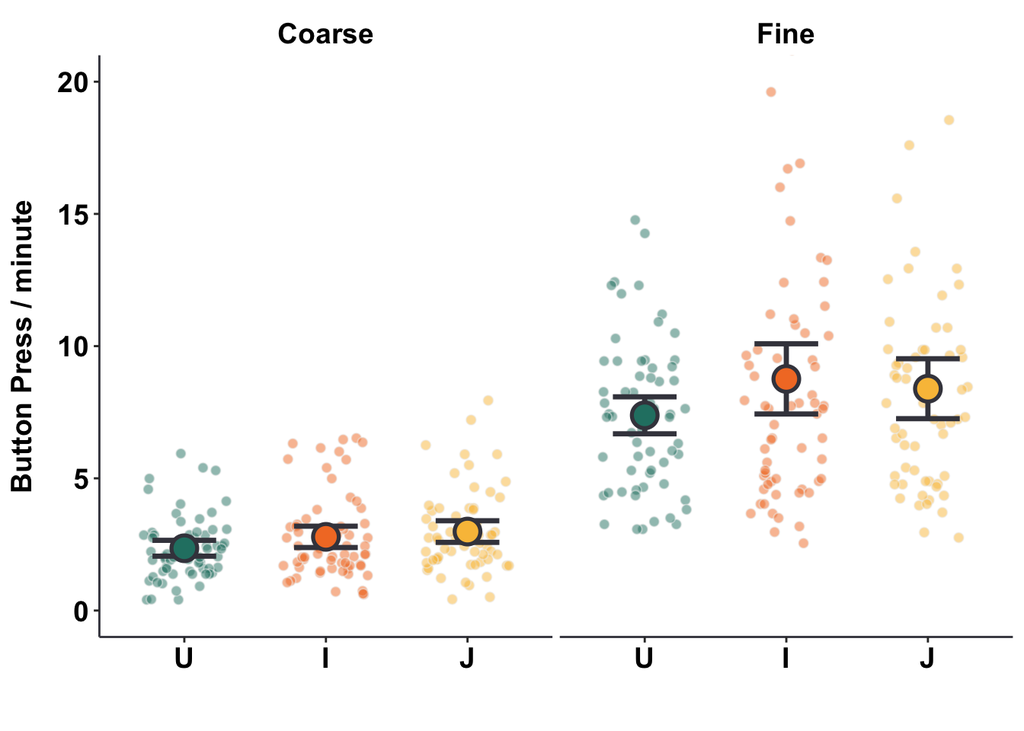

```r
#data frame to plot significance line
ann_line<-data.frame(xStart=c(1),xEnd= c(2), yStart=c(15.5),yEnd=c(15.5),
    grain=factor(c("f"),levels=grain.factor))
ann_text<-data.frame(x=c(1.5), y=c(16.2),
    text = c("*"),
    grain=factor(c("f"),levels=grain.factor))

esKnow1.bpRate_plot <- ggplot(esKnow1.bp, aes(x = condition, y = bpRate, fill = condition, color = condition))+
  geom_jitter(width = jitter.width, alpha = jitter.alpha-.2, shape = point.shape, color = jitter.outline, size = jitter.size)+
  stat_summary(geom = "errorbar", fun.data = "mean_cl_normal", width = errorbar.width +.15, color = outline.color, alpha = errorbar.alpha, size = errorbar.size)+
  geom_point(stat = "summary", fun = "mean", size = point.size, shape = point.shape, color = outline.color, stroke = point.stroke, legend = FALSE)+
  #geom_signif()+
  scale_fill_manual(values = colors$point.colors, labels = NULL, guide = "none")+
  scale_color_manual(values = colors$point.colors, labels = NULL, guide = "none")+
  scale_x_discrete(labels=c("U", "I", "J"))+
  #geom_segment(data = ann_line, aes(x = xStart, y = yStart, xend = xEnd, yend = yEnd), inherit.aes = FALSE, color = outline.color, size = 0.5) +
  #geom_text(data = ann_text, aes(x = x, y = y, label = text), inherit.aes = FALSE, color = outline.color, size = 8, fontface = txt.face) +
  facet_wrap(~grain, scales = "fixed", labeller = labeller(grain = c("c" = "Coarse", "f" = "Fine")))+
  coord_cartesian(ylim=c(0, 20))+
  labs(y = "Button Press / minute", x = "") +
  theme.esKnow

esKnow1.bpRate_plot
```

```r
# setwd('../plots/')
# ggsave("esKnow1.bpRate_plot_longer.pdf", plot = esKnow1.bpRate_plot, width = 6, height = 4, device = cairo_pdf)
# pdf_convert(pdf = "esKnow1.bpRate_plot_longer.pdf", format = "png", dpi = 300,
#             filenames = "esKnow1.bpRate_plot_longer.png")
```

Fine segmentation > coarse segmentation (as expected). There is an influence of condition on segmentation rate, but no interaction with grain. Segmentation rate of interrupted condition is higher than uninterrupted, but all other comparisons (interrupted vs jumbled and unintterupted vs jumbled) are comparable. This may show potential but minimal influence of interrupting videos on frequency of boundary identification.

### Hierarchical organization

**Calculate alignment and enclosure measures**

```r
esKnow1.alignment = data.frame()

for(movie in unique(esKnow1.segmentdata$movName)){
  for(cond in unique(esKnow1.segmentdata$condition)){
    segment.data <- esKnow1.segmentdata[esKnow1.segmentdata$condition == cond ,]
    get.alignment <- function(id){
      coarse.bp <- sort(segment.data$bpTime.series[segment.data$subid == id &
                                                segment.data$movName == movie &
                                                segment.data$grain == 'c'])
      fine.bp <- sort(segment.data$bpTime.series[segment.data$subid == id &
                                                   segment.data$movName == movie &
                                                   segment.data$grain == 'f'])
      grainorder <- unique(segment.data$grainorder[segment.data$subid == id &
                                                   segment.data$movName == movie &
                                                   segment.data$grain == 'f'])

      nearest.fine <- do.call(rbind, foreach(i = coarse.bp) %do% fine.bp[which.min(abs(i-fine.bp))])
      nearest.fine.sign <- sign(coarse.bp - nearest.fine)

      ##alignment
      nearest.null <- (diff(fine.bp)/2)^2
      Ave.Dist <- mean(abs(coarse.bp - nearest.fine))
      Ave.Dist.null <- ((fine.bp[1]^2)/2 + sum(nearest.null))/fine.bp[length(fine.bp)]
      alignment.value = Ave.Dist.null - Ave.Dist

      return(data.frame(subid = id, movName = factor(movie, levels = movie.factor), condition = factor(cond, levels = condition.factor), grainorder = factor(grainorder, levels = c(1,2)),alignment = alignment.value, enclosure = mean((nearest.fine.sign+1)/2)))
    }
    esKnow1.alignment <- rbind(esKnow1.alignment, do.call(rbind, lapply(unique(segment.data$subid), get.alignment)))
  }
}
```

**Analyze alignment values** *Build and compare linear models*

```r
esKnow1.alignment.lmer <- lmer(alignment~condition + grainorder + movName + (1|subid), data = esKnow1.alignment)
esKnow1.alignment.lmer_B <- lmer(alignment~condition*grainorder + movName + (1|subid), data = esKnow1.alignment)
esKnow1.alignment.lmer_C <- lmer(alignment~condition*movName + grainorder + (1|subid), data = esKnow1.alignment)
esKnow1.alignment.lmer_D <- lmer(alignment~condition*movName*grainorder + (1|subid), data = esKnow1.alignment)

anova(esKnow1.alignment.lmer, esKnow1.alignment.lmer_B)
```

```
## Data: esKnow1.alignment
## Models:
## esKnow1.alignment.lmer: alignment ~ condition + grainorder + movName + (1 | subid)
## esKnow1.alignment.lmer_B: alignment ~ condition * grainorder + movName + (1 | subid)
##                          npar    AIC    BIC  logLik deviance  Chisq Df
## esKnow1.alignment.lmer      7 573.65 596.30 -279.82   559.65
## esKnow1.alignment.lmer_B    9 576.32 605.45 -279.16   558.32 1.3244  2
##                          Pr(>Chisq)
## esKnow1.alignment.lmer
## esKnow1.alignment.lmer_B     0.5157
```

```r
anova(esKnow1.alignment.lmer, esKnow1.alignment.lmer_C)
```

```
## Data: esKnow1.alignment
## Models:
## esKnow1.alignment.lmer: alignment ~ condition + grainorder + movName + (1 | subid)
## esKnow1.alignment.lmer_C: alignment ~ condition * movName + grainorder + (1 | subid)
##                          npar    AIC    BIC  logLik deviance Chisq Df
## esKnow1.alignment.lmer      7 573.65 596.30 -279.82   559.65
## esKnow1.alignment.lmer_C    9 577.65 606.77 -279.82   559.65 0.001  2
##                          Pr(>Chisq)
## esKnow1.alignment.lmer
## esKnow1.alignment.lmer_C     0.9995
```

```r
anova(esKnow1.alignment.lmer, esKnow1.alignment.lmer_D)
```

```
## Data: esKnow1.alignment
## Models:
## esKnow1.alignment.lmer: alignment ~ condition + grainorder + movName + (1 | subid)
## esKnow1.alignment.lmer_D: alignment ~ condition * movName * grainorder + (1 | subid)
##                          npar    AIC    BIC  logLik deviance  Chisq Df
## esKnow1.alignment.lmer      7 573.65 596.30 -279.82   559.65
## esKnow1.alignment.lmer_D   14 582.00 627.31 -277.00   554.00 5.6441  7
##                          Pr(>Chisq)
## esKnow1.alignment.lmer
## esKnow1.alignment.lmer_D     0.5819
```

Adding movie and grain order as interaction did not improve model fit, so use simpler model for subsequent analyses

*Test for effects*

```r
joint_tests(esKnow1.alignment.lmer)
```

```
##  model term df1    df2 F.ratio p.value
##  condition    2 159.84   1.680  0.1897
##  grainorder   1  32.49   4.149  0.0499
##  movName      1 150.33   1.638  0.2025
```

No effect of condition on alignment values.

*Check if alignment values are above chance*

```r
summary(emmeans(esKnow1.alignment.lmer, "condition"), infer=TRUE)
```

```
##  condition     emmean    SE  df lower.CL upper.CL t.ratio p.value
##  Uninterrupted  0.657 0.144 117    0.372    0.941   4.571  <.0001
##  Interrupted    0.804 0.144 116    0.520    1.089   5.596  <.0001
##  Jumbled        1.003 0.148 121    0.710    1.297   6.763  <.0001
##
## Results are averaged over the levels of: grainorder, movName
## Degrees-of-freedom method: kenward-roger
## Confidence level used: 0.95
```

All alignment values are significantly above chance.

**Analyze enclosure values** *Build and compare linear models*

```r
esKnow1.enclosure.lmer <- lmer(enclosure~condition + grainorder + movName + (1|subid), data = esKnow1.alignment)
esKnow1.enclosure.lmer_B <- lmer(enclosure~condition*grainorder + movName + (1|subid), data = esKnow1.alignment)
esKnow1.enclosure.lmer_C <- lmer(enclosure~condition*movName + grainorder + (1|subid), data = esKnow1.alignment)
esKnow1.enclosure.lmer_D <- lmer(enclosure~condition*grainorder*movName + (1|subid), data = esKnow1.alignment)

anova(esKnow1.enclosure.lmer, esKnow1.enclosure.lmer_B)
```

```
## Data: esKnow1.alignment
## Models:
## esKnow1.enclosure.lmer: enclosure ~ condition + grainorder + movName + (1 | subid)
## esKnow1.enclosure.lmer_B: enclosure ~ condition * grainorder + movName + (1 | subid)
##                          npar     AIC     BIC logLik deviance  Chisq Df
## esKnow1.enclosure.lmer      7 -197.27 -174.61 105.63  -211.27
## esKnow1.enclosure.lmer_B    9 -198.11 -168.98 108.06  -216.11 4.8424  2
##                          Pr(>Chisq)
## esKnow1.enclosure.lmer
## esKnow1.enclosure.lmer_B    0.08881 .
## ---
## Signif. codes:  0 '***' 0.001 '**' 0.01 '*' 0.05 '.' 0.1 ' ' 1
```

```r
anova(esKnow1.enclosure.lmer, esKnow1.enclosure.lmer_C)
```

```
## Data: esKnow1.alignment
## Models:
## esKnow1.enclosure.lmer: enclosure ~ condition + grainorder + movName + (1 | subid)
## esKnow1.enclosure.lmer_C: enclosure ~ condition * movName + grainorder + (1 | subid)
##                          npar     AIC     BIC logLik deviance  Chisq Df
## esKnow1.enclosure.lmer      7 -197.27 -174.61 105.63  -211.27
## esKnow1.enclosure.lmer_C    9 -194.18 -165.05 106.09  -212.18 0.9129  2
##                          Pr(>Chisq)
## esKnow1.enclosure.lmer
## esKnow1.enclosure.lmer_C     0.6335
```

```r
anova(esKnow1.enclosure.lmer, esKnow1.enclosure.lmer_D)
```

```
## Data: esKnow1.alignment
## Models:
## esKnow1.enclosure.lmer: enclosure ~ condition + grainorder + movName + (1 | subid)
## esKnow1.enclosure.lmer_D: enclosure ~ condition * grainorder * movName + (1 | subid)
##                          npar     AIC     BIC logLik deviance  Chisq Df
## esKnow1.enclosure.lmer      7 -197.27 -174.61 105.63  -211.27
## esKnow1.enclosure.lmer_D   14 -190.09 -144.78 109.04  -218.09 6.8189  7
##                          Pr(>Chisq)
## esKnow1.enclosure.lmer
## esKnow1.enclosure.lmer_D      0.448
```

Adding movie and grainorder interaction did not improve model fit, so use simpler model for subsequent analyses.

**Test for effects**

```r
joint_tests(esKnow1.enclosure.lmer)
```

```
##  model term df1    df2 F.ratio p.value
##  condition    2 160.75   2.268  0.1068
##  grainorder   1  31.95  11.105  0.0022
##  movName      1 150.92   1.500  0.2225
```

No effect of condition on enclosure values.

**Check if enclosure values are above chance**

```r
summary(emmeans(esKnow1.enclosure.lmer, "condition", null = 0.5), infer=TRUE)
```

```
##  condition     emmean     SE  df lower.CL upper.CL null t.ratio p.value
##  Uninterrupted  0.615 0.0177 139    0.580    0.650  0.5   6.491  <.0001
##  Interrupted    0.572 0.0177 138    0.537    0.607  0.5   4.074  0.0001
##  Jumbled        0.620 0.0184 140    0.584    0.656  0.5   6.539  <.0001
##
## Results are averaged over the levels of: grainorder, movName
## Degrees-of-freedom method: kenward-roger
## Confidence level used: 0.95
```

Enclosure values in all conditions were above chance.

**Plot measures of hierarchy**

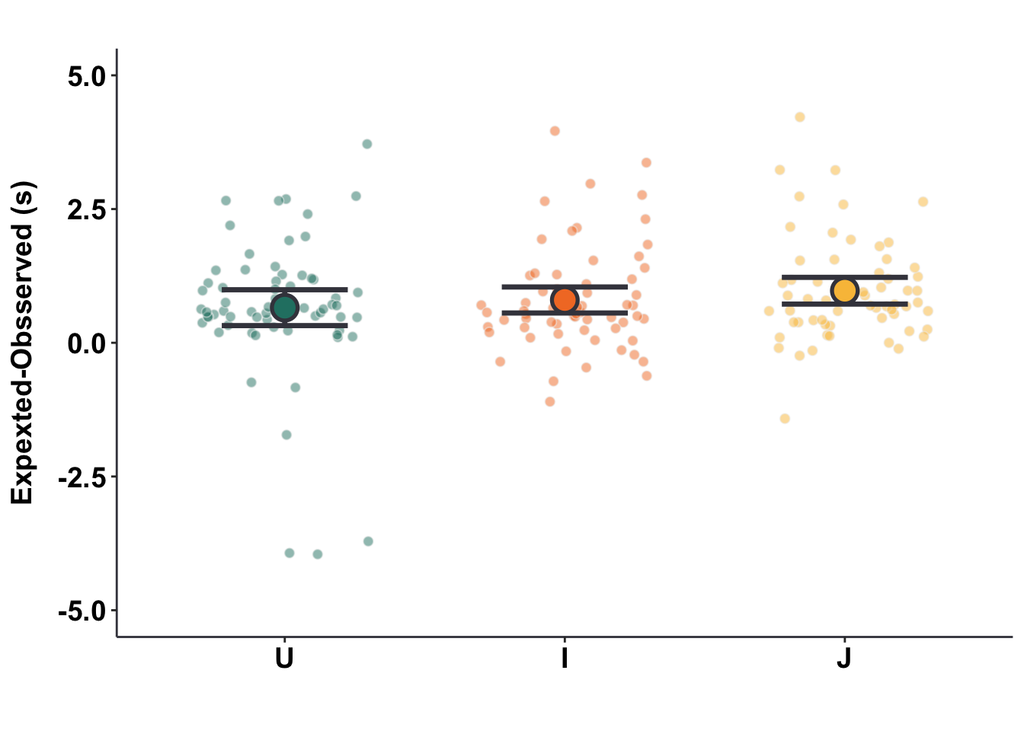

```r
###Plot alignment values
esKnow1.alignment.plot <- ggplot(esKnow1.alignment, aes(condition, alignment, fill = condition, color = condition))+
  geom_jitter(width = jitter.width, alpha = jitter.alpha - .2, show.legend = FALSE, shape = point.shape, color = jitter.outline, size = jitter.size)+
  stat_summary(geom = "errorbar", fun.data = "mean_cl_normal", width = errorbar.width + .15, color = outline.color, alpha = errorbar.alpha, size = errorbar.size)+
  geom_point(stat = "summary", fun = "mean", size = point.size, alpha = point.alpha, shape = point.shape, color = outline.color, stroke = point.stroke, show.lengend = FALSE)+
  scale_fill_manual(values = colors$point.colors, labels = NULL, guide = "none")+
  scale_color_manual(values = colors$point.colors, labels = NULL, guide = "none")+
  scale_x_discrete(labels=c("U", "I", "J"))+
  coord_cartesian(ylim = c(-5, 5))+
  labs(y = "Expexted-Obsserved (s)", x = "", title = "")+
  theme.esKnow

esKnow1.alignment.plot
```

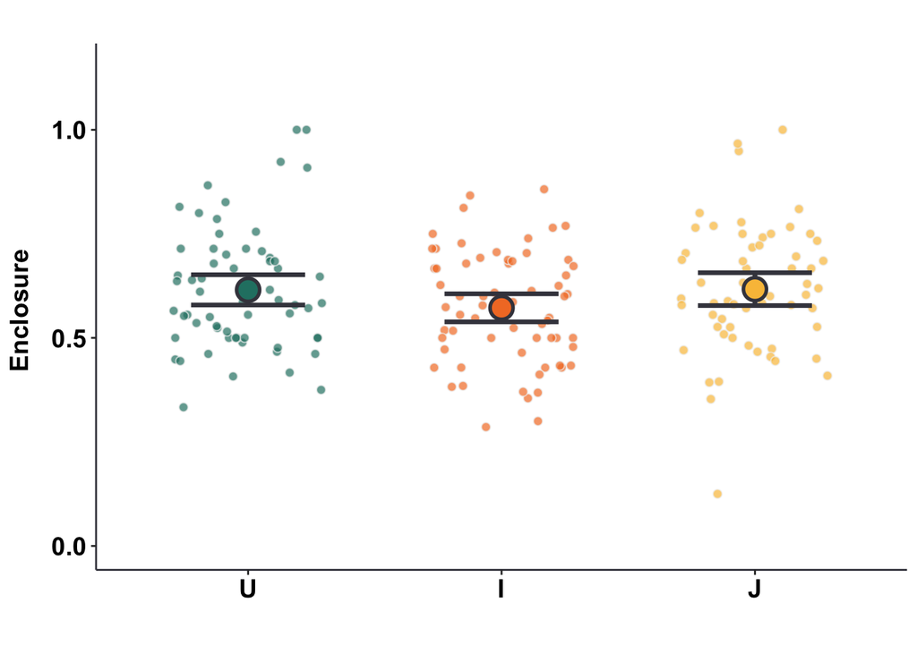

```r
# setwd('../plots/')
# ggsave("esKnow1_alignment.png", plot = esKnow1.alignment.plot, width = 3, height = 4, bg = "transparent")

# setwd('../plots/')
# ggsave("esKnow1_alignment.pdf", plot = esKnow1.alignment.plot, width = 3.5, height = 4, device = cairo_pdf)
# pdf_convert(pdf = "esKnow1_alignment.pdf", format = "png", dpi = 300,
#             filenames = "esKnow1_alignment.png")

esKnow1.enclosure.plot <- ggplot(esKnow1.alignment, aes(condition, enclosure, fill = condition, color = condition))+
                                  geom_jitter(width = jitter.width, alpha = jitter.alpha, show.legend = FALSE, shape = point.shape, color = jitter.outline, size = jitter.size)+
  stat_summary(geom = "errorbar", fun.data = "mean_cl_normal", width = errorbar.width + .15, color = outline.color, size = errorbar.size)+
  geom_point(stat = "summary", fun = "mean", size = point.size, alpha = point.alpha, shape = point.shape, color = outline.color, stroke = point.stroke, show.lengend = FALSE)+
  scale_fill_manual(values = colors$point.colors, labels = NULL, guide = "none")+
  scale_color_manual(values = colors$point.colors, labels = NULL, guide = "none")+
  scale_x_discrete(labels=c("U", "I", "J"))+
  scale_y_continuous(breaks = c(0, 0.5, 1), labels = c('0.0', '0.5', '1.0')) +
  coord_cartesian(ylim = c(0,1.15)) +
  #geom_segment(aes(x = 1, y = 1.1, xend = 2, yend = 1.1), color = outline.color, size = 0.5) +
  #annotate("text", x = 1.5, y = 1.15, label = "**", color = outline.color, size = 8) +
  labs(x = "", y = "Enclosure ", title = "")+
  theme.esKnow

esKnow1.enclosure.plot
```

```r
# setwd('../plots/')
# ggsave("esKnow1_enclosure.png", plot = esKnow1.enclosure.plot, width = 3, height = 4, bg = "transparent")
# ggsave("esKnow1_enclosure.pdf", plot = esKnow1.enclosure.plot, width = 3.5, height = 4, device = cairo_pdf)
# pdf_convert(pdf = "esKnow1_enclosure.pdf", format = "png", dpi = 300,
#             filenames = "esKnow1_enclosure.png")
```

Disruptions in information flow do not influence how people hierarchically organize events.

### Agrement Index

**Calculate agreement index** - comparing each individual to other individuals in the same condition - comparing each individual with other other individuals in different conditions

```r
# esKnow1.agreement.index <- data.frame()
# for(cond in unique(esKnow1.segmentdata$condition)){
#   for (segGrain in unique(esKnow1.segmentdata$grain)){
#     for (movieName in unique(esKnow1.segmentdata$movName)){
#       crossConds <- unique(esKnow1.segmentdata$condition)[unique(esKnow1.segmentdata$condition) != cond]
#
#       dat <- esKnow1.segmentdata[esKnow1.segmentdata$condition == cond & esKnow1.segmentdata$grain == segGrain & esKnow1.segmentdata$movName == movieName,]
#       crossdat <- esKnow1.segmentdata[esKnow1.segmentdata$condition != cond & esKnow1.segmentdata$grain == segGrain & esKnow1.segmentdata$movName == movieName,]
#
#       if(movieName == "3Iron"){
#         mov.dur = iron.mov.dur
#       } else {mov.dur = corn.mov.dur}
#
#       #define timeseries
#       timeseries <- seq(from = 1, to = mov.dur, by = bin.size)
#
#       for(sub in unique(dat$subid)){
#         grainorder <- unique(dat$grainorder[dat$subid == sub])
#         sub.ts <- as.numeric(timeseries %in% floor(dat$bpTime.series[dat$subid == sub]))
#
#         gp.timeseries <- unlist(tapply(dat$bpTime.series[dat$subid != sub], dat$subid[dat$subid!=sub], function(x){return(as.numeric(timeseries %in% floor(x)))}))
#         gp.ts <- tapply(gp.timeseries, rep(timeseries, length(unique(dat$subid))-1), mean)
#
#         #get random timeseries
#         random.timeseries <- unlist(tapply(gp.timeseries, rep(sample(length(unique(dat$subid))-1), each = length(timeseries)), sample))
#         random.ts <- tapply(random.timeseries, rep(timeseries, length(unique(dat$subid))-1), mean)
#
#         comparisons <- c(cond, "random")
#         agreements <- rbind(get.agreement.index(sub.ts, gp.ts), get.agreement.index(sub.ts, random.ts))
#
#         for(crossCond in crossConds){
#           crossgp.bp <- crossdat$bpTime.series[crossdat$condition == crossCond]
#           crossgp.timeseries <- unlist(tapply(crossgp.bp, crossdat$subid[crossdat$condition == crossCond], function(x){return(as.numeric(timeseries %in% floor(x)))}))
#           crossgp.ts <- tapply(crossgp.timeseries, rep(timeseries, length(unique(crossdat$subid[crossdat$condition == crossCond]))), mean)
#           comparisons <- c(comparisons, crossCond)
#           agreements <- rbind(agreements, get.agreement.index(sub.ts, crossgp.ts))
#         }
#
#         comp_types <- c("same", "random", "crossCond", "crossCond")
#
#         esKnow1.agreement.index <- rbind(esKnow1.agreement.index, data.frame(subid = rep(sub, length(comparisons)),
#                                                                              indiv_cond = factor(rep(cond, length(comparisons)), levels = condition.factor),
#                                                                              movName = factor(rep(movieName, length(comparisons)), levels = movie.factor),
#                                                                              grain = factor(rep(segGrain, length(comparisons)), levels = grain.factor),
#                                                                              group_cond = factor(comparisons, levels = c(condition.factor, "random")),
#                                                                              comparison_type = factor(comp_types),
#                                                                              grainorder = factor(rep(grainorder, length(comparisons)), levels = c(1,2)),
#                                                                              min_corr = agreements[,1],
#                                                                              max_corr = agreements[,2],
#                                                                              act_corr = agreements[,3],
#                                                                              agreementIndex = agreements[,4]))
#       }
#     }
#   }
# }

# #save agreement index values
#write.table(esKnow1.agreement.index, "../data/esKnow1_agreementIndex.csv", row.names = FALSE, sep = ",")

##Load previously saved agreement index values
esKnow1.agreement.index <- read.csv("../data/esKnow1_agreementIndex.csv", head = TRUE)
```

If interrupting or jumbling videos influence segmentation pattern, we can expect that compared to agreement within uninterrupted group (i.e., uninterrupted individuals compared with uninterrupted group): Poorer agreement when interrupted or jumbled individuals are compared with uninterrupted group

**Build and compare models**

```r
#test for (1)
esKnow.agreement.withU <- esKnow1.agreement.index %>% dplyr::filter(group_cond == "Uninterrupted") %>% droplevels()
esKnow.agreement.withU.lmer <- lmer(agreementIndex~indiv_cond*grain + grainorder + movName + (1+grain|subid), data = esKnow.agreement.withU)
esKnow.agreement.withU.lmer.B <- lmer(agreementIndex~indiv_cond*grain* grainorder + movName + (1|subid), data = esKnow.agreement.withU)
esKnow.agreement.withU.lmer.C <- lmer(agreementIndex~indiv_cond*grain*movName + grainorder + (1|subid), data = esKnow.agreement.withU)
esKnow.agreement.withU.lmer.D <- lmer(agreementIndex~indiv_cond*grain*movName*grainorder + (1|subid), data = esKnow.agreement.withU)
anova(esKnow.agreement.withU.lmer, esKnow.agreement.withU.lmer.B)
```

```
## Data: esKnow.agreement.withU
## Models:
## esKnow.agreement.withU.lmer: agreementIndex ~ indiv_cond * grain + grainorder + movName + (1 + grain | subid)
## esKnow.agreement.withU.lmer.B: agreementIndex ~ indiv_cond * grain * grainorder + movName + (1 | subid)
##                               npar     AIC     BIC logLik deviance  Chisq Df
## esKnow.agreement.withU.lmer     12 -675.73 -628.58 349.87  -699.73
## esKnow.agreement.withU.lmer.B   15 -682.59 -623.64 356.29  -712.59 12.858  3
##                               Pr(>Chisq)
## esKnow.agreement.withU.lmer
## esKnow.agreement.withU.lmer.B   0.004954 **
## ---
## Signif. codes:  0 '***' 0.001 '**' 0.01 '*' 0.05 '.' 0.1 ' ' 1
```

```r
anova(esKnow.agreement.withU.lmer, esKnow.agreement.withU.lmer.C)
```

```
## Data: esKnow.agreement.withU
## Models:
## esKnow.agreement.withU.lmer: agreementIndex ~ indiv_cond * grain + grainorder + movName + (1 + grain | subid)
## esKnow.agreement.withU.lmer.C: agreementIndex ~ indiv_cond * grain * movName + grainorder + (1 | subid)
##                               npar     AIC     BIC logLik deviance  Chisq Df
## esKnow.agreement.withU.lmer     12 -675.73 -628.58 349.87  -699.73
## esKnow.agreement.withU.lmer.C   15 -670.55 -611.60 350.27  -700.55 0.8177  3
##                               Pr(>Chisq)
## esKnow.agreement.withU.lmer
## esKnow.agreement.withU.lmer.C     0.8452
```

```r
anova(esKnow.agreement.withU.lmer, esKnow.agreement.withU.lmer.D)
```

```
## Data: esKnow.agreement.withU
## Models:
## esKnow.agreement.withU.lmer: agreementIndex ~ indiv_cond * grain + grainorder + movName + (1 + grain | subid)
## esKnow.agreement.withU.lmer.D: agreementIndex ~ indiv_cond * grain * movName * grainorder + (1 | subid)
##                               npar     AIC     BIC logLik deviance  Chisq Df
## esKnow.agreement.withU.lmer     12 -675.73 -628.58 349.87  -699.73
## esKnow.agreement.withU.lmer.D   26 -667.32 -565.15 359.66  -719.32 19.591 14
##                               Pr(>Chisq)
## esKnow.agreement.withU.lmer
## esKnow.agreement.withU.lmer.D     0.1436
```

Adding grain order as interaction term improved model fit so use this model for subsequent analyses

**Test for main and interaction effects**

```r
joint_tests(esKnow.agreement.withU.lmer.B)
```

```
##  model term                  df1    df2 F.ratio p.value
##  indiv_cond                    2 346.94   0.665  0.5149
##  grain                         1 329.87 361.754  <.0001
##  grainorder                    1 329.87   1.500  0.2216
##  movName                       1 329.87   2.133  0.1451
##  indiv_cond:grain              2 329.87   0.605  0.5465
##  indiv_cond:grainorder         2 329.87   1.917  0.1487
##  grain:grainorder              1  32.89   0.780  0.3835
##  indiv_cond:grain:grainorder   2 346.94   4.193  0.0159
```

```r
eta_squared(esKnow.agreement.withU.lmer.B)
```

```
## # Effect Size for ANOVA (Type III)
##
## Parameter                   | Eta2 (partial) |       90% CI
## -----------------------------------------------------------
## indiv_cond                  |       8.14e-03 | [0.00, 0.03]
## grain                       |           0.41 | [0.20, 0.57]
## grainorder                  |       4.54e-03 | [0.00, 0.02]
## movName                     |       6.45e-03 | [0.00, 0.03]
## indiv_cond:grain            |           0.03 | [0.00, 0.06]
## indiv_cond:grainorder       |           0.01 | [0.00, 0.03]
## grain:grainorder            |           0.02 | [0.00, 0.17]
## indiv_cond:grain:grainorder |           0.02 | [0.00, 0.05]
```

There is no main effect of individual condition on agreement index, suggesting that when compared to Uninterrupted group, Interrupted and Jumbled individuals performed similarly to uninterrupted individuals (as measured by agreement index)

There is a significant conditionxgrainxgrainorder interaction.

**Pairwise comparison to test for interaction effects**

```r
summary(emmeans(esKnow.agreement.withU.lmer.B, c("grain", "grainorder"), by = c("indiv_cond")))
```

```
## indiv_cond = Interrupted:
##  grain grainorder emmean     SE  df lower.CL upper.CL
##  c              1  0.385 0.0181 218    0.350    0.421
##  f              1  0.538 0.0181 207    0.502    0.574
##  c              2  0.354 0.0181 207    0.318    0.390
##  f              2  0.552 0.0181 218    0.516    0.587
##
## indiv_cond = Jumbled:
##  grain grainorder emmean     SE  df lower.CL upper.CL
##  c              1  0.326 0.0192 239    0.288    0.364
##  f              1  0.567 0.0181 205    0.531    0.603
##  c              2  0.379 0.0181 205    0.344    0.415
##  f              2  0.529 0.0192 239    0.491    0.566
##
## indiv_cond = Uninterrupted:
##  grain grainorder emmean     SE  df lower.CL upper.CL
##  c              1  0.353 0.0180 222    0.317    0.389
##  f              1  0.539 0.0181 205    0.503    0.575
##  c              2  0.404 0.0181 205    0.369    0.440
##  f              2  0.560 0.0180 222    0.524    0.595
##
## Results are averaged over the levels of: movName
## Degrees-of-freedom method: kenward-roger
## Confidence level used: 0.95
```

```r
summary(emmeans(esKnow.agreement.withU.lmer.B, c("grain"), by = c("grainorder", "indiv_cond"),
                contr = list(coarsevsfine = c(-.5, .5)), weights = "proportional", adjust = "holm")$contrasts, infer = TRUE)
```

```
## grainorder = 1, indiv_cond = Interrupted:
##  contrast     estimate     SE  df lower.CL upper.CL t.ratio p.value
##  coarsevsfine   0.0763 0.0128 213   0.0511    0.102   5.969  <.0001
##
## grainorder = 2, indiv_cond = Interrupted:
##  contrast     estimate     SE  df lower.CL upper.CL t.ratio p.value
##  coarsevsfine   0.0989 0.0128 213   0.0737    0.124   7.737  <.0001
##
## grainorder = 1, indiv_cond = Jumbled:
##  contrast     estimate     SE  df lower.CL upper.CL t.ratio p.value
##  coarsevsfine   0.1204 0.0132 222   0.0943    0.146   9.117  <.0001
##
## grainorder = 2, indiv_cond = Jumbled:
##  contrast     estimate     SE  df lower.CL upper.CL t.ratio p.value
##  coarsevsfine   0.0746 0.0132 222   0.0486    0.101   5.650  <.0001
##
## grainorder = 1, indiv_cond = Uninterrupted:
##  contrast     estimate     SE  df lower.CL upper.CL t.ratio p.value
##  coarsevsfine   0.0930 0.0128 213   0.0678    0.118   7.279  <.0001
##
## grainorder = 2, indiv_cond = Uninterrupted:
##  contrast     estimate     SE  df lower.CL upper.CL t.ratio p.value
##  coarsevsfine   0.0776 0.0128 213   0.0524    0.103   6.071  <.0001
##
## Results are averaged over the levels of: movName
## Degrees-of-freedom method: kenward-roger
## Confidence level used: 0.95
```

```r
summary(emmeans(esKnow.agreement.withU.lmer.B, c("grain", "grainorder"), by = c("indiv_cond"),
                contr = list(firstvssecond = c(-.5, .5, .5, -.5)), weights = "proportional", adjust = "holm")$contrasts, infer = TRUE)
```

```
## indiv_cond = Interrupted:
##  contrast      estimate     SE  df lower.CL upper.CL t.ratio p.value
##  firstvssecond  -0.0226 0.0198 100 -0.06182   0.0166  -1.144  0.2554
##
## indiv_cond = Jumbled:
##  contrast      estimate     SE  df lower.CL upper.CL t.ratio p.value
##  firstvssecond   0.0458 0.0204 106  0.00539   0.0862   2.247  0.0267
##
## indiv_cond = Uninterrupted:
##  contrast      estimate     SE  df lower.CL upper.CL t.ratio p.value
##  firstvssecond   0.0154 0.0198 100 -0.02374   0.0546   0.782  0.4361
##
## Results are averaged over the levels of: movName
## Degrees-of-freedom method: kenward-roger
## Confidence level used: 0.95
```

In all condition and regardless of whether they performed coarse or fine segmentation first, agreement index with uninterrupted group for fine segmentation is higher than agreement index with uninterrupted group for coarse segmentation.

**Plot**

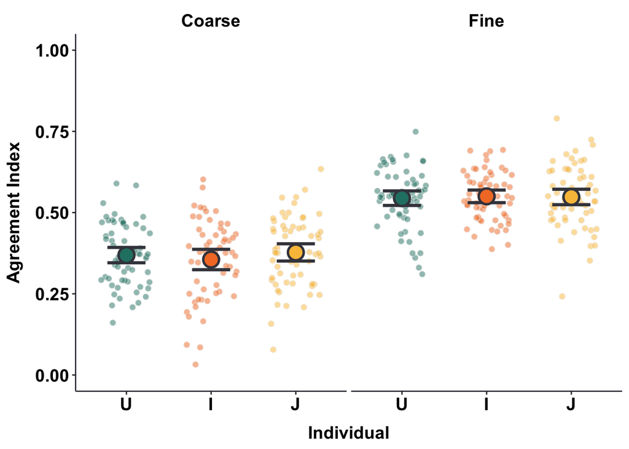

```r
esKnow1.agreementIndex_indivVSUgroup_plot <- ggplot(esKnow.agreement.withU, aes(x = indiv_cond, y = agreementIndex, fill = indiv_cond, color = indiv_cond))+
  geom_jitter(width = jitter.width, alpha = jitter.alpha-.2, shape = point.shape, color = jitter.outline, size = jitter.size)+
  stat_summary(geom = "errorbar", fun.data = "mean_cl_normal", width = errorbar.width +.15, color = outline.color, alpha = errorbar.alpha, size = errorbar.size)+
  geom_point(stat = "summary", fun = "mean", size = point.size, shape = point.shape, color = outline.color, stroke = point.stroke, legend = FALSE)+
  #geom_signif()+
  scale_fill_manual(values = colors$point.colors, labels = NULL, guide = "none")+
  scale_color_manual(values = colors$point.colors, labels = NULL, guide = "none")+
  scale_x_discrete(labels=c("U", "I", "J"))+
  facet_wrap(~grain, scales = "fixed", labeller = labeller(grain = c("c" = "Coarse", "f" = "Fine")))+
  coord_cartesian(ylim=c(0, 1))+
  labs(y = "Agreement Index", x = "Individual") +
  theme.esKnow
esKnow1.agreementIndex_indivVSUgroup_plot
```

```r
# setwd('../plots/')
# ggsave("esKnow1_agreement_indivVSUgroup.pdf", plot = esKnow1.agreementIndex_indivVSUgroup_plot, width = 6, height = 4, device = cairo_pdf)
# pdf_convert(pdf = "esKnow1_agreement_indivVSUgroup.pdf", format = "png", dpi = 300,
#             filenames = "esKnow1_agreement_indivVSUgroup.png")
```

From analysis of agreement index, there seems to be minimal evidence for influence of interrupting or jumbling videos on segmentation pattern over time.

### Evaluate button press at shorter intervals within each clip

Minimal evidence for effect of disruption in information flow on segmentation may suggest that there is enough information contained within each 1 minute clip for segmentation (i.e., segmentation may rely on information accumulated over shorter timescale). So, look at more potential for more localized difference in segmentation across conditions.

**Calculate button press rates at every 5s interval of each one minute clip.**

```r
time.intervals <- seq(from = 1, to = esKnow1.nsegment, by = 1)
n.clip <- length(unique(esKnow1.segmentdata$clipNo))
esKnow1.segmentdata$clipTwelft <- factor(ceiling(esKnow1.segmentdata$bpTime/5), levels = time.intervals)

esKnow1.bp5sec <- esKnow1.segmentdata %>% dplyr::group_by(subid, condition, movName, grain, grainorder,clipTwelft) %>% dplyr::summarise(n.bp = n()/n.clip) %>% complete(clipTwelft, fill = list(n.bp = 0)) %>% drop_na(clipTwelft)
```

**Build and compare models**

```r
esKnow1.bp5sec.lmer <- lmer(n.bp~condition*grain*clipTwelft +grainorder+ movName + (1|subid), data = esKnow1.bp5sec)
esKnow1.bp5sec.lmer_B <- lmer(n.bp~condition*grain*clipTwelft*grainorder + movName + (1|subid), data = esKnow1.bp5sec)
esKnow1.bp5sec.lmer_C <- lmer(n.bp~condition*grain*clipTwelft*movName + grainorder + (1|subid), data = esKnow1.bp5sec)
esKnow1.bp5sec.lmer_D <- lmer(n.bp~condition*grain*clipTwelft*movName*grainorder + (1|subid), data = esKnow1.bp5sec)


anova(esKnow1.bp5sec.lmer, esKnow1.bp5sec.lmer_B)
```

```
## Data: esKnow1.bp5sec
## Models:
## esKnow1.bp5sec.lmer: n.bp ~ condition * grain * clipTwelft + grainorder + movName + (1 | subid)
## esKnow1.bp5sec.lmer_B: n.bp ~ condition * grain * clipTwelft * grainorder + movName + (1 | subid)
##                       npar    AIC    BIC  logLik deviance  Chisq Df Pr(>Chisq)
## esKnow1.bp5sec.lmer     76 1210.0 1697.5 -529.00  1057.99
## esKnow1.bp5sec.lmer_B  147 1250.2 2193.2 -478.12   956.23 101.76 71   0.009757
##
## esKnow1.bp5sec.lmer
## esKnow1.bp5sec.lmer_B **
## ---
## Signif. codes:  0 '***' 0.001 '**' 0.01 '*' 0.05 '.' 0.1 ' ' 1
```

```r
anova(esKnow1.bp5sec.lmer, esKnow1.bp5sec.lmer_C)
```

```
## Data: esKnow1.bp5sec
## Models:
## esKnow1.bp5sec.lmer: n.bp ~ condition * grain * clipTwelft + grainorder + movName + (1 | subid)
## esKnow1.bp5sec.lmer_C: n.bp ~ condition * grain * clipTwelft * movName + grainorder + (1 | subid)
##                       npar    AIC    BIC  logLik deviance  Chisq Df Pr(>Chisq)
## esKnow1.bp5sec.lmer     76 1210.0 1697.5 -529.00  1057.99
## esKnow1.bp5sec.lmer_C  147 1229.2 2172.1 -467.61   935.21 122.78 71  0.0001344
##
## esKnow1.bp5sec.lmer
## esKnow1.bp5sec.lmer_C ***
## ---
## Signif. codes:  0 '***' 0.001 '**' 0.01 '*' 0.05 '.' 0.1 ' ' 1
```

```r
anova(esKnow1.bp5sec.lmer, esKnow1.bp5sec.lmer_D)
```

```
## Data: esKnow1.bp5sec
## Models:
## esKnow1.bp5sec.lmer: n.bp ~ condition * grain * clipTwelft + grainorder + movName + (1 | subid)
## esKnow1.bp5sec.lmer_D: n.bp ~ condition * grain * clipTwelft * movName * grainorder + (1 | subid)
##                       npar    AIC    BIC  logLik deviance  Chisq  Df Pr(>Chisq)
## esKnow1.bp5sec.lmer     76 1210.0 1697.5 -529.00  1057.99
## esKnow1.bp5sec.lmer_D  290 1362.6 3222.8 -391.29   782.58 275.41 214   0.002929
##
## esKnow1.bp5sec.lmer
## esKnow1.bp5sec.lmer_D **
## ---
## Signif. codes:  0 '***' 0.001 '**' 0.01 '*' 0.05 '.' 0.1 ' ' 1
```

Adding movieName and grainorder as interactions improved model fit.So use the most complex model for subsequent analyses.

```r
emm_options(pbkrtest.limit = 4512)
joint_tests(esKnow1.bp5sec.lmer_D)
```

```
##  model term                                    df1     df2  F.ratio p.value
##  condition                                       2 4219.69   28.323  <.0001
##  grain                                           1 4190.01 2946.878  <.0001
##  clipTwelft                                     11 4190.01    7.540  <.0001
##  movName                                         1 4190.01   54.185  <.0001
##  grainorder                                      1 4190.01   39.755  <.0001
##  condition:grain                                 2 4190.01    8.426  0.0002
##  condition:clipTwelft                           22 4190.01    2.461  0.0002
##  condition:movName                               2 4190.01    1.762  0.1719
##  condition:grainorder                            2 4190.01    4.972  0.0070
##  grain:clipTwelft                               11 4190.01    1.206  0.2767
##  grain:movName                                   1 4190.01    9.460  0.0021
##  grain:grainorder                                1   33.93    0.187  0.6679
##  clipTwelft:movName                             11 4190.01    6.791  <.0001
##  clipTwelft:grainorder                          11 4190.01    0.574  0.8513
##  movName:grainorder                              1 4190.01    0.764  0.3820
##  condition:grain:clipTwelft                     22 4190.01    0.148  1.0000
##  condition:grain:movName                         2 4190.01    1.538  0.2150
##  condition:grain:grainorder                      2 4219.69   30.661  <.0001
##  condition:clipTwelft:movName                   22 4190.01    0.325  0.9988
##  condition:clipTwelft:grainorder                22 4190.01    0.402  0.9940
##  condition:movName:grainorder                    2 4190.01    0.824  0.4387
##  grain:clipTwelft:movName                       11 4190.01    1.366  0.1817
##  grain:clipTwelft:grainorder                    11 4190.01    0.273  0.9907
##  grain:movName:grainorder                        1 4190.01    1.882  0.1701
##  clipTwelft:movName:grainorder                  11 4190.01    0.907  0.5324
##  condition:grain:clipTwelft:movName             22 4190.01    0.325  0.9988
##  condition:grain:clipTwelft:grainorder          22 4190.01    0.474  0.9819
##  condition:grain:movName:grainorder              2 4190.01    2.957  0.0521
##  condition:clipTwelft:movName:grainorder        22 4190.01    0.446  0.9878
##  grain:clipTwelft:movName:grainorder            11 4190.01    0.429  0.9439
##  condition:grain:clipTwelft:movName:grainorder  22 4190.01    0.492  0.9770
```

```r
eta_squared(esKnow1.bp5sec.lmer_D, partial = TRUE)
```

```
## # Effect Size for ANOVA (Type III)
##
## Parameter                                     | Eta2 (partial) |       90% CI
## -----------------------------------------------------------------------------
## condition                                     |           0.01 | [0.01, 0.02]
## grain                                         |           0.41 | [0.40, 0.43]
## clipTwelft                                    |           0.02 | [0.01, 0.02]
## movName                                       |           0.01 | [0.01, 0.02]
## grainorder                                    |       9.40e-03 | [0.01, 0.01]
## condition:grain                               |       4.01e-03 | [0.00, 0.01]
## condition:clipTwelft                          |           0.01 | [0.00, 0.01]
## grain:clipTwelft                              |       3.16e-03 | [0.00, 0.00]
## condition:movName                             |       8.40e-04 | [0.00, 0.00]
## grain:movName                                 |       2.25e-03 | [0.00, 0.01]
## clipTwelft:movName                            |           0.02 | [0.01, 0.02]
## condition:grainorder                          |       2.37e-03 | [0.00, 0.01]
## grain:grainorder                              |       5.49e-03 | [0.00, 0.11]
## clipTwelft:grainorder                         |       1.51e-03 | [0.00, 0.00]
## movName:grainorder                            |       1.82e-04 | [0.00, 0.00]
## condition:grain:clipTwelft                    |       7.75e-04 | [0.00, 0.00]
## condition:grain:movName                       |       7.34e-04 | [0.00, 0.00]
## condition:clipTwelft:movName                  |       1.70e-03 | [0.00, 0.00]
## grain:clipTwelft:movName                      |       3.57e-03 | [0.00, 0.00]
## condition:grain:grainorder                    |           0.01 | [0.01, 0.02]
## condition:clipTwelft:grainorder               |       2.11e-03 | [0.00, 0.00]
## grain:clipTwelft:grainorder                   |       7.15e-04 | [0.00, 0.00]
## condition:movName:grainorder                  |       3.93e-04 | [0.00, 0.00]
## grain:movName:grainorder                      |       4.49e-04 | [0.00, 0.00]
## clipTwelft:movName:grainorder                 |       2.38e-03 | [0.00, 0.00]
## condition:grain:clipTwelft:movName            |       1.70e-03 | [0.00, 0.00]
## condition:grain:clipTwelft:grainorder         |       2.48e-03 | [0.00, 0.00]
## condition:grain:movName:grainorder            |       1.41e-03 | [0.00, 0.00]
## condition:clipTwelft:movName:grainorder       |       2.34e-03 | [0.00, 0.00]
## grain:clipTwelft:movName:grainorder           |       1.12e-03 | [0.00, 0.00]
## condition:grain:clipTwelft:movName:grainorder |       2.58e-03 | [0.00, 0.00]
```

Condition*clipTwelft interaction: evidence for difference in n.bp between conditions across the 5s intervals.

Test for main effect of 5s segment by grain and condition

```r
#main effect of time by grain and condition
test(contrast(emmeans(esKnow1.bp5sec.lmer_D, "clipTwelft", by = c( "condition", "grain"), type = "response", weights = "proportional", adjust = "holm"), "trt.vs.ctrl"), joint = TRUE)
```

```
##  condition     grain df1     df2 F.ratio p.value
##  Uninterrupted c      11 4190.01   0.616  0.8165
##  Interrupted   c      11 4190.01   0.601  0.8297
##  Jumbled       c      11 4190.01   3.760  <.0001
##  Uninterrupted f      11 4190.01   1.749  0.0574
##  Interrupted   f      11 4190.01   0.901  0.5387
##  Jumbled       f      11 4190.01   6.065  <.0001
```

Test for difference in bp every interval for J vs U vs I

```r
#main effect of time by grain and condition
summary(emmeans(esKnow1.bp5sec.lmer_D, "condition", by = c( "clipTwelft", "grain"), type = "response", weights = "proportional", adjust = "holm", contr ="pairwise")$contrasts, infer = TRUE)
```

```
## clipTwelft = 1, grain = c:
##  contrast                     estimate     SE   df lower.CL  upper.CL t.ratio
##  Uninterrupted - Interrupted -9.45e-04 0.0476 4192  -0.1150  0.113148  -0.020
##  Uninterrupted - Jumbled     -2.09e-01 0.0485 4193  -0.3248 -0.092409  -4.300
##  Interrupted - Jumbled       -2.08e-01 0.0485 4192  -0.3238 -0.091553  -4.283
##  p.value
##   0.9842
##   0.0001
##   0.0001
##
## clipTwelft = 2, grain = c:
##  contrast                     estimate     SE   df lower.CL  upper.CL t.ratio
##  Uninterrupted - Interrupted -7.20e-03 0.0476 4192  -0.1213  0.106898  -0.151
##  Uninterrupted - Jumbled      1.28e-02 0.0485 4193  -0.1034  0.129020   0.264
##  Interrupted - Jumbled        2.00e-02 0.0485 4192  -0.0961  0.136126   0.413
##  p.value
##   1.0000
##   1.0000
##   1.0000
##
## clipTwelft = 3, grain = c:
##  contrast                     estimate     SE   df lower.CL  upper.CL t.ratio
##  Uninterrupted - Interrupted -4.47e-02 0.0476 4192  -0.1588  0.069398  -0.938
##  Uninterrupted - Jumbled     -1.71e-02 0.0485 4193  -0.1333  0.099109  -0.352
##  Interrupted - Jumbled        2.76e-02 0.0485 4192  -0.0885  0.143715   0.570
##  p.value
##   1.0000
##   1.0000
##   1.0000
##
## clipTwelft = 4, grain = c:
##  contrast                     estimate     SE   df lower.CL  upper.CL t.ratio
##  Uninterrupted - Interrupted -2.13e-02 0.0476 4192  -0.1354  0.092835  -0.446
##  Uninterrupted - Jumbled     -2.13e-02 0.0485 4193  -0.1375  0.094868  -0.440
##  Interrupted - Jumbled       -6.55e-05 0.0485 4192  -0.1162  0.116036  -0.001
##  p.value
##   1.0000
##   1.0000
##   1.0000
##
```

[output cut: 190 more lines]

```
## clipTwelft = 12, grain = f:
##  contrast                     estimate     SE   df lower.CL  upper.CL t.ratio
##  Uninterrupted - Interrupted -1.35e-01 0.0476 4192  -0.2494 -0.021227  -2.841
##  Uninterrupted - Jumbled     -4.61e-02 0.0485 4193  -0.1623  0.070091  -0.950
##  Interrupted - Jumbled        8.92e-02 0.0485 4192  -0.0269  0.205322   1.840
##  p.value
##   0.0136
##   0.3421
##   0.1316
##
## Results are averaged over the levels of: movName, grainorder
## Degrees-of-freedom method: kenward-roger
## Confidence level used: 0.95
## Conf-level adjustment: bonferroni method for 3 estimates
## P value adjustment: holm method for 3 tests
```

Investigate whether effect of 5s segment for fine Uninterrupted is meaningful. Extract significant pairwise difference between 5s segment for fine uninterrupted.

```r
t <- summary(emmeans(esKnow1.bp5sec.lmer_D, "clipTwelft", by = c("grain", "condition"), contr = "pairwise", adjust = "Holm")$contrasts, infer= TRUE)
t[t$grain == "f"&t$condition == "Uninterrupted" & t$p.value <= .05,]
```

```
##  [1] contrast  grain     condition estimate  SE        df        lower.CL
##  [8] upper.CL  t.ratio   p.value
## <0 rows> (or 0-length row.names)
```

```r
t
```

```
## grain = c, condition = Uninterrupted:
##  contrast  estimate     SE   df lower.CL upper.CL t.ratio p.value
##  1 - 2     0.054688 0.0476 4190 -0.10563   0.2150   1.150  1.0000
##  1 - 3    -0.018750 0.0476 4190 -0.17906   0.1416  -0.394  1.0000
##  1 - 4    -0.003125 0.0476 4190 -0.16344   0.1572  -0.066  1.0000
##  1 - 5     0.006250 0.0476 4190 -0.15406   0.1666   0.131  1.0000
##  1 - 6     0.017188 0.0476 4190 -0.14313   0.1775   0.361  1.0000
##  1 - 7    -0.006250 0.0476 4190 -0.16656   0.1541  -0.131  1.0000
##  1 - 8     0.007812 0.0476 4190 -0.15250   0.1681   0.164  1.0000
##  1 - 9     0.017188 0.0476 4190 -0.14313   0.1775   0.361  1.0000
##  1 - 10    0.023438 0.0476 4190 -0.13688   0.1838   0.493  1.0000
##  1 - 11    0.039062 0.0476 4190 -0.12125   0.1994   0.821  1.0000
##  1 - 12    0.071875 0.0476 4190 -0.08844   0.2322   1.511  1.0000
##  2 - 3    -0.073438 0.0476 4190 -0.23375   0.0869  -1.544  1.0000
##  2 - 4    -0.057813 0.0476 4190 -0.21813   0.1025  -1.215  1.0000
```

[output cut: 404 more lines]

Extract significant pairwise difference between 5s segment for coarse Jumbled

```r
t[t$grain == 'c' & t$condition == "Jumbled" & t$p.value <= .05,]
```

```
##     contrast grain condition  estimate         SE       df    lower.CL
## 265    1 - 2     c   Jumbled 0.2761161 0.04923548 4190.011 0.110176298
## 266    1 - 3     c   Jumbled 0.1727679 0.04923548 4190.011 0.006828084
## 267    1 - 4     c   Jumbled 0.1841518 0.04923548 4190.011 0.018212012
## 268    1 - 5     c   Jumbled 0.2020089 0.04923548 4190.011 0.036069155
## 269    1 - 6     c   Jumbled 0.1890625 0.04923548 4190.011 0.023122727
## 271    1 - 8     c   Jumbled 0.1812500 0.04923548 4190.011 0.015310227
## 272    1 - 9     c   Jumbled 0.1676339 0.04923548 4190.011 0.001694155
## 273   1 - 10     c   Jumbled 0.2142857 0.04923548 4190.011 0.048345941
## 274   1 - 11     c   Jumbled 0.2584821 0.04923548 4190.011 0.092542370
## 275   1 - 12     c   Jumbled 0.1937500 0.04923548 4190.011 0.027810227
##      upper.CL  t.ratio      p.value
## 265 0.4420558 5.608071 1.437289e-06
## 266 0.3387076 3.509011 2.636132e-02
## 267 0.3500916 3.740225 1.117881e-02
## 268 0.3679487 4.102914 2.619123e-03
## 269 0.3550023 3.839964 7.617039e-03
## 271 0.3471898 3.681288 1.386384e-02
## 272 0.3335737 3.404738 3.810430e-02
## 273 0.3802255 4.352262 8.828930e-04
## 274 0.4244219 5.249916 1.038103e-05
## 275 0.3596898 3.935170 5.238090e-03
```

```r
min(t$t.ratio[t$grain == 'c' & t$condition == "Jumbled" & t$p.value <= 0.05])
```

```
## [1] 3.404738
```

```r
max(t$p.value[t$grain == 'c' & t$condition == "Jumbled" & t$p.value <= 0.05])
```

```
## [1] 0.0381043
```

```r
min(t$upper.CL[t$grain == 'c' & t$condition == "Jumbled" & t$p.value <= .05] - t$lower.CL[t$grain == 'c' & t$condition == "Jumbled" & t$p.value <= .05])
```

```
## [1] 0.3318795
```

Extract significant pairwise difference between 5s segment for fine Jumbled

```r
t[t$grain == 'f' & t$condition == "Jumbled" & t$p.value <= .05,]
```

```
##     contrast grain condition  estimate         SE       df   lower.CL  upper.CL
## 331    1 - 2     f   Jumbled 0.3169643 0.04923548 4190.011 0.15102451 0.4829041
## 332    1 - 3     f   Jumbled 0.2183036 0.04923548 4190.011 0.05236380 0.3842433
## 333    1 - 4     f   Jumbled 0.2517857 0.04923548 4190.011 0.08584594 0.4177255
## 334    1 - 5     f   Jumbled 0.2821429 0.04923548 4190.011 0.11620308 0.4480826
## 335    1 - 6     f   Jumbled 0.2625000 0.04923548 4190.011 0.09656023 0.4284398
## 336    1 - 7     f   Jumbled 0.2535714 0.04923548 4190.011 0.08763166 0.4195112
## 337    1 - 8     f   Jumbled 0.2868304 0.04923548 4190.011 0.12089058 0.4527701
## 338    1 - 9     f   Jumbled 0.2223214 0.04923548 4190.011 0.05638166 0.3882612
## 339   1 - 10     f   Jumbled 0.2819196 0.04923548 4190.011 0.11597987 0.4478594
## 340   1 - 11     f   Jumbled 0.3142857 0.04923548 4190.011 0.14834594 0.4802255
## 341   1 - 12     f   Jumbled 0.3162946 0.04923548 4190.011 0.15035487 0.4822344
##      t.ratio      p.value
## 331 6.437721 8.905709e-09
## 332 4.433867 5.315974e-04
## 333 5.113908 1.912020e-05
## 334 5.730478 6.645167e-07
## 335 5.331521 6.151381e-06
## 336 5.150177 1.605952e-05
## 337 5.825684 3.852222e-07
## 338 4.515472 3.699988e-04
## 339 5.725945 6.713632e-07
## 340 6.383317 1.229658e-08
## 341 6.424120 9.583459e-09
```

```r
min(t$t.ratio[t$grain == 'f' & t$condition == "Jumbled" & t$p.value <= 0.05])
```

```
## [1] 4.433867
```

```r
max(t$p.value[t$grain == 'f' & t$condition == "Jumbled" & t$p.value <= 0.05])
```

```
## [1] 0.0005315974
```

```r
min(t$upper.CL[t$grain == 'f' & t$condition == "Jumbled" & t$p.value <= .05] - t$lower.CL[t$grain == 'f' & t$condition == "Jumbled" & t$p.value <= .05])
```

```
## [1] 0.3318795
```

First 5s segment has consistently higher bp for both fine and coarse Jumbled segmentation.

[Jumbled - (Uninterrupted & Interrupted)] in the first 5 seconds vs the rest of time

```r
#Jumbled - (uninterrupted & interrupted) in the first 5 seconds vs the rest of time
summary(emmeans(esKnow1.bp5sec.lmer_D, c("condition", "clipTwelft"), by = "grain", contr = list(JvsUI = c(-.5,-.5, 1,.5/11,.5/11,-1/11,.5/11,.5/11,-1/11,.5/11,.5/11,-1/11,.5/11,.5/11,-1/11,.5/11,.5/11,-1/11,.5/11,.5/11,-1/11,.5/11,.5/11,-1/11,.5/11,.5/11,-1/11,.5/11,.5/11,-1/11,.5/11,.5/11,-1/11,.5/11,.5/11,-1/11)), adjust = "holm")$contrasts, infer = T)
```

```
## grain = c:
##  contrast estimate    SE   df lower.CL upper.CL t.ratio p.value
##  JvsUI       0.199 0.044 4190    0.113    0.285   4.517  <.0001
##
## grain = f:
##  contrast estimate    SE   df lower.CL upper.CL t.ratio p.value
##  JvsUI       0.210 0.044 4190    0.123    0.296   4.759  <.0001
##
## Results are averaged over the levels of: movName, grainorder
## Degrees-of-freedom method: kenward-roger
## Confidence level used: 0.95
```

There is an increase in button press for Jumbled condition during the first 5 second of a new 1 min clip, but this stabilizes after 5s (difference between Jumbled and (Uninterrupted & Interrupted) is significantly higher in the first 5 seconds vs the rest of the clip).

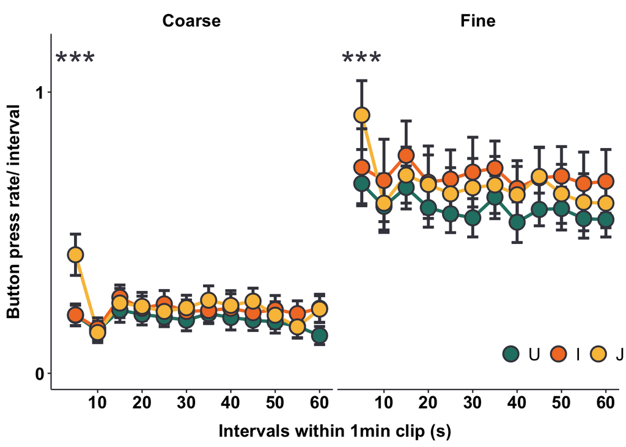

```r
esKnow1.bp5sec.plot <- ggplot(esKnow1.bp5sec, aes(x = clipTwelft, y = n.bp, fill = condition, color = condition))+
  #geom_jitter(width = jitter.width, alpha = 0.1, show.legend = FALSE)+
  #geom_line(stat = "summary", fun = "mean", size = .8)+
  stat_summary(aes(y = n.bp, group = condition), fun.y = mean, geom = "line", size = 1.25, show.legend = FALSE)+
  stat_summary(geom = "errorbar", fun.data = "mean_cl_normal", width = errorbar.width + .2, color = outline.color, alpha = 1.2, size = 1.1)+
  geom_point(stat = "summary", fun = "mean", size = point.size, alpha = point.alpha, shape = 21, color = outline.color, stroke = 1.1, show.lengend = FALSE)+
  scale_fill_manual(values = colors$point.colors, labels = c("U", "I", "J"))+
  scale_color_manual(values = colors$point.colors, labels = c("U", "I", "J"))+
  scale_x_discrete(breaks = c(2,4,6,8,10,12), labels = c("10", "20", "30", "40", "50", "60"))+
  scale_y_continuous(breaks = c(0,1), labels = c("0", "1"))+
  facet_wrap(~grain, scales = "fixed", labeller = labeller(grain = c("c" = "Coarse", "f" = "Fine")))+
  coord_cartesian(ylim=c(0, 1.15), xlim = c(0.5,12))+
  labs(y = "Button press rate/ interval", x = "Intervals within 1min clip (s)")+
  annotate("text", x = 1, y = 1.1, label = "***", color = outline.color, size = 10)+
  theme(axis.title.y = element_text(margin = margin(t = 0, r = 10, b = 0, l = 0)))+
  theme(axis.title.x = element_text(margin = margin(t = 15, r = 0, b = 0, l = 0)))+
  theme(legend.position = c(.9,.1), legend.background=element_blank(), legend.direction = "horizontal")+
  theme(legend.text=element_text(size=txt.size), plot.caption = element_text(size = txt.size))+
  theme.esKnow


esKnow1.bp5sec.plot
```

```r
# setwd('../plots_transparentBG/')
# ggsave("esKnow1_bp5Sec_wlegend.png", plot = esKnow1.bp5sec.plot, width = 7, height = 4, bg = "transparent")
#
# setwd('../plots/')
# ggsave("esKnow1_bp5Sec.pdf", plot = esKnow1.bp5sec.plot, width = 9, height = 4, device = cairo_pdf)
# pdf_convert(pdf = "esKnow1_bp5Sec.pdf", format = "png", dpi = 300,
#             filenames = "esKnow1_bp5Sec.png")
```

## Experiment 1 segmentation behavior conclusion

Adding discontinuity and incoherence in information flow minimally impacts overall segmentation. When information cannot be accumulated coherently over time, segmentation rate briefly increase but quickly stabilizes when information can be accumulated coherently beyond 5 seconds.

## Create figure for segmentation results from esKnow (Figure 2)

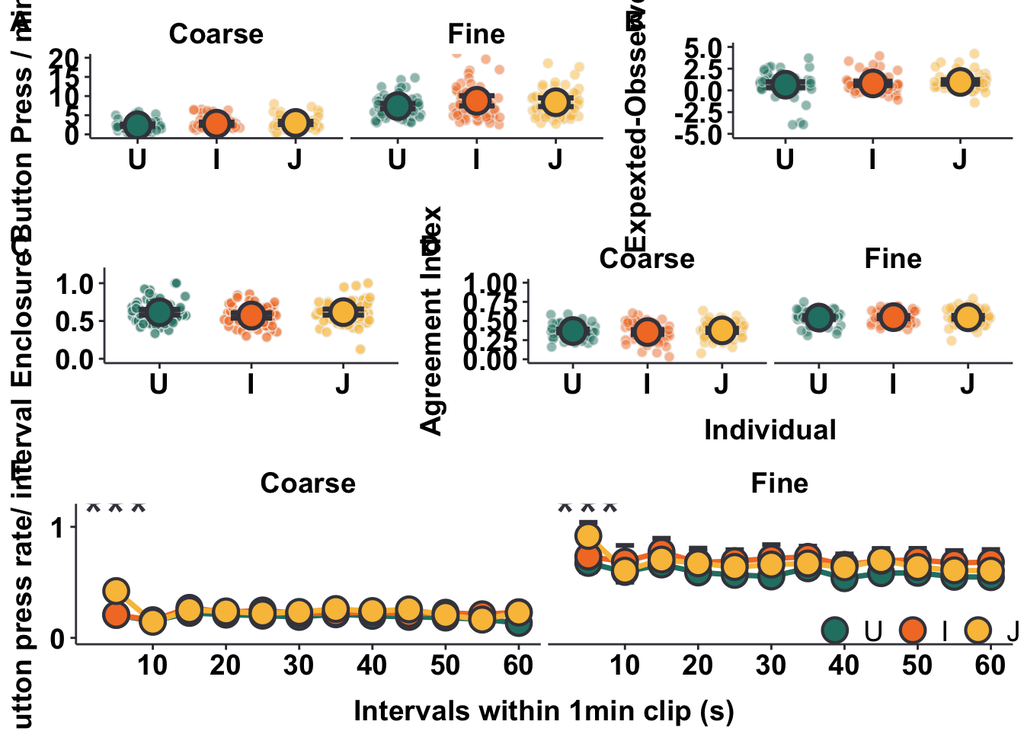

```r
fig2_top <- ggarrange(esKnow1.bpRate_plot, esKnow1.alignment.plot,
                      widths = c(1.2, 0.8),
                     labels = c("A", "B"),
                     ncol = 2, nrow = 1)
fig2_middle <- ggarrange(esKnow1.enclosure.plot, esKnow1.agreementIndex_indivVSUgroup_plot,
                         widths = c(0.8, 1.2),
                         labels = c("C", "D"),
                         ncol = 2, nrow = 1)
figure2 <- ggarrange(fig2_top, fig2_middle, esKnow1.bp5sec.plot,
                     heights = c(1.2,1.2,1.5),
                     labels = c("", "", "E"),
                     ncol = 1, nrow = 3)

# fig2_top <- ggarrange(esKnow1.bpRate_plot, esKnow1.agreementIndex_indivVSUgroup_plot,
# labels = c("A", "B"), ncol = 2, nrow = 1)
# fig2_middle <- ggarrange(esKnow1.coarse.dens, esKnow1.fine.dens, ncol = 1, nrow = 2, common.legend = TRUE)
# figure2 <- ggarrange(fig2_top, fig2_middle, esKnow1.bp5sec.plot,
#                      heights = c(1,1.2, 1.2),
#                      labels = c('', 'C', 'D'),
#                      ncol = 1, nrow = 3)
figure2
```

```r
# setwd('../plots/')
# ggsave("esKnow1_figure2.pdf", plot = figure2, width = 9, height = 11, device = cairo_pdf)
# pdf_convert(pdf = "esKnow1_figure2.pdf", format = "png", dpi = 300,
#             filenames = "esKnow1_figure2.png")
```

## Recall performance

### Overall recall rate

*Calculate recall rate*

```r
esKnow1.recallRate <- esKnow1.recall %>%
  dplyr::group_by(condition, exp_subid, movName, separated) %>%
  dplyr::summarise(nRecall = sum(recall)) %>%
  dplyr::mutate(recallRate = case_when(separated & movName == "3Iron" ~ nRecall/length(iron_separated),
                                       !separated & movName == "3Iron" ~ nRecall/(nEvents_iron_fine - length(iron_separated)),
                                       separated & movName == "Corn" ~ nRecall/length(corn_separated),
                                       !separated & movName == "Corn" ~ nRecall/(nEvents_corn_fine - length(corn_separated))))

esKnow1.recallRate$condition <- factor(esKnow1.recallRate$condition, levels = condition.factor)
```

*Build and compare models for recall rate*

```r
esKnow1.recall.lmer <- lmer(recallRate~condition*separated + movName + (1|exp_subid), data = esKnow1.recallRate)
esKnow1.recall.lmer.B <- lmer(recallRate~condition*separated*movName + (1|exp_subid), data = esKnow1.recallRate)

anova(esKnow1.recall.lmer, esKnow1.recall.lmer.B)
```

```
## Data: esKnow1.recallRate
## Models:
## esKnow1.recall.lmer: recallRate ~ condition * separated + movName + (1 | exp_subid)
## esKnow1.recall.lmer.B: recallRate ~ condition * separated * movName + (1 | exp_subid)
##                       npar     AIC     BIC logLik deviance  Chisq Df Pr(>Chisq)
## esKnow1.recall.lmer      9 -184.15 -148.88 101.07  -202.15
## esKnow1.recall.lmer.B   14 -198.45 -143.59 113.23  -226.45 24.304  5  0.0001897
##
## esKnow1.recall.lmer
## esKnow1.recall.lmer.B ***
## ---
## Signif. codes:  0 '***' 0.001 '**' 0.01 '*' 0.05 '.' 0.1 ' ' 1
```

Adding movie as interaction improved model fit, so use more complex model for subsequent analyses.

*Test for effects on recall rate*

```r
joint_tests(esKnow1.recall.lmer.B)
```

```
##  model term                  df1    df2 F.ratio p.value
##  condition                     2 342.99  20.498  <.0001
##  separated                     1 325.69  15.247  0.0001
##  movName                       1 326.23  60.306  <.0001
##  condition:separated           2 325.69   0.017  0.9835
##  condition:movName             2 325.69   4.521  0.0116
##  separated:movName             1 325.69  14.600  0.0002
##  condition:separated:movName   2 325.69   0.297  0.7430
```

```r
eta_squared(esKnow1.recall.lmer.B, partial = TRUE)
```

```
## # Effect Size for ANOVA (Type III)
##
## Parameter                   | Eta2 (partial) |       90% CI
## -----------------------------------------------------------
## condition                   |           0.11 | [0.06, 0.16]
## separated                   |           0.04 | [0.02, 0.09]
## movName                     |           0.16 | [0.10, 0.22]
## condition:separated         |       1.03e-04 | [0.00, 0.00]
## condition:movName           |           0.03 | [0.00, 0.06]
## separated:movName           |           0.04 | [0.01, 0.08]
## condition:separated:movName |       1.82e-03 | [0.00, 0.01]
```

Main effect of condition suggest that jumbling or interrupting videos influence overall recall rate. Main effect of separated suggest that recall rates differ for separated vs intact events but this effect is consistent across condition (no condition*separated interaction).

*Compare marginal effect of condition on recall rate*

```r
summary(emmeans(esKnow1.recall.lmer.B, "condition", by =c("movName"), contr = "pairwise", weights = "proportional", adjust = "holm")$contrasts, infer = TRUE)
```

```
## movName = 3Iron:
##  contrast                    estimate     SE  df  lower.CL upper.CL t.ratio
##  Uninterrupted - Interrupted   0.0818 0.0309 335  7.49e-03   0.1561   2.649
##  Uninterrupted - Jumbled       0.2079 0.0315 337  1.32e-01   0.2836   6.605
##  Interrupted - Jumbled         0.1261 0.0314 334  5.06e-02   0.2016   4.019
##  p.value
##   0.0085
##   <.0001
##   0.0001
##
## movName = Corn:
##  contrast                    estimate     SE  df  lower.CL upper.CL t.ratio
##  Uninterrupted - Interrupted   0.0115 0.0315 336 -6.42e-02   0.0873   0.367
##  Uninterrupted - Jumbled       0.0758 0.0315 337  4.46e-05   0.1515   2.407
##  Interrupted - Jumbled         0.0642 0.0320 336 -1.27e-02   0.1411   2.009
##  p.value
##   0.7138
##   0.0498
##   0.0906
##
## Results are averaged over the levels of: separated
## Degrees-of-freedom method: kenward-roger
## Confidence level used: 0.95
## Conf-level adjustment: bonferroni method for 3 estimates
## P value adjustment: holm method for 3 tests
```

*Compare marginal effects of event separation on recall rate.*

```r
summary(emmeans(esKnow1.recall.lmer.B, "separated", contr = "revpairwise", weights = "proportional", adjust = "holm")$contrasts, infer = TRUE)
```

```
##  contrast     estimate    SE  df lower.CL upper.CL t.ratio p.value
##  TRUE - FALSE   0.0708 0.018 326   0.0355    0.106   3.945  0.0001
##
## Results are averaged over the levels of: condition, movName
## Degrees-of-freedom method: kenward-roger
## Confidence level used: 0.95
```

Separated events are remembered at a higher rate compared to intact events, maybe a reflection of systamtic differences in scene memorability (supplementary figure S2).

*Plot recall rate*

```r
esKnow1.recallRate.ann <- data.frame(xstart = c(1, 1, 2, 1), xend = c(3, 2, 3, 3),
                                     ystart = c(1.15, 1, 0.85, 1.15), yend = c(1.15, 1, 0.85, 1.15),
                                     x = c(2, 1.5, 2.5, 2), y = c(1.2,1.05, 0.9, 1.27),
                                     label = c("***", "**", "***", "~"),
                                     movName = c("3Iron", "3Iron", "3Iron", "Corn"))

esKnow1.recallRate_plot <- ggplot(esKnow1.recallRate, aes(x = condition, y = recallRate, fill = interaction(condition, separated), color = interaction(condition, separated)))+
  geom_jitter(alpha = 0.3, position = position_jitterdodge(.7), size = jitter.size, shape = point.shape, color = jitter.outline)+
  stat_summary(geom = "errorbar", fun.data = "mean_cl_normal", width = errorbar.width+0.2, color = outline.color, alpha = errorbar.alpha, position =position_dodge(0.5), size = 1) +
  geom_point(stat = "summary", fun = "mean", size = point.size, shape = 21, color = outline.color, position = position_dodge(0.5), stroke = 1.2) +
  scale_fill_manual(values = colors$point.colors)+
  scale_color_manual(values = colors$point.colors)+
  scale_x_discrete(labels=c("Uninterrupted" = "U", "Interrupted" = "I",
                              "Jumbled" = "J"))+
  facet_wrap(~movName)+
  # geom_segment(aes(x = 2, y = 1.05, xend = 3, yend = 1.05), color = outline.color, size = 0.5) +
  # annotate("text", x = 2.5, y = 1.08, label = "*", color = outline.color, size = 8) +
  geom_segment(data = esKnow1.recallRate.ann, aes(x = xstart, y = ystart, xend = xend, yend = yend), color = outline.color, size = 1, inherit.aes = FALSE) +
  geom_text(data = esKnow1.recallRate.ann, aes(x = x, y = y, label = label), color = outline.color, size = 8, inherit.aes = FALSE) +
  coord_cartesian(ylim = c(0,1.3))+
  scale_y_continuous(breaks = c(0.0, 0.5, 1.0), labels = c('0.0', '0.5', '1.0'))+
  labs(y = "Recall rate", x = "")+
  theme(legend.position = 'none') +
  theme.esKnow

# esKnow1.recallRate_plot
# setwd('../plots_transparentBG/')
# ggsave("esKnow1_recallRate.png", plot = esKnow1.recallRate_plot, width = 4, height = 4, bg = "transparent")
#
# setwd('../plots/')
# ggsave("esKnow1_recallRate_separated.pdf", plot = esKnow1.recallRate_plot, width = 5, height = 4, device = cairo_pdf)
# pdf_convert(pdf = "esKnow1_recallRate_separated.pdf", format = "png", dpi = 300,
#             filenames = "esKnow1_recallRate_separated.png")
```

However, there’s also significantly higher recall rate for separated events for 3Iron that is consistent across conditions. There may be something ‘special’ about these events. One potential is that scenes in separated events are somehow more memorable. Inspect memorability scores for separated vs intact events (Supplementary).

**Semantic clustering**

```r
esKnow1.semanticClust.lmer <- lmer(semantic_clustering~condition*event_condition + movName + (1|exp_subid), data = esKnow1.clustering)
esKnow1.semanticClust.lmer.B <- lmer(semantic_clustering~condition*event_condition*movName + (1|exp_subid), data = esKnow1.clustering)

anova(esKnow1.semanticClust.lmer, esKnow1.semanticClust.lmer.B)
```

```
## Data: esKnow1.clustering
## Models:
## esKnow1.semanticClust.lmer: semantic_clustering ~ condition * event_condition + movName + (1 | exp_subid)
## esKnow1.semanticClust.lmer.B: semantic_clustering ~ condition * event_condition * movName + (1 | exp_subid)
##                              npar     AIC     BIC logLik deviance  Chisq Df
## esKnow1.semanticClust.lmer      9 -386.06 -351.18 202.03  -404.06
## esKnow1.semanticClust.lmer.B   14 -395.43 -341.18 211.72  -423.43 19.374  5
##                              Pr(>Chisq)
## esKnow1.semanticClust.lmer
## esKnow1.semanticClust.lmer.B   0.001637 **
## ---
## Signif. codes:  0 '***' 0.001 '**' 0.01 '*' 0.05 '.' 0.1 ' ' 1
```

```r
joint_tests(esKnow1.semanticClust.lmer.B)
```

```
##  model term                        df1    df2 F.ratio p.value
##  condition                           2 331.97   5.402  0.0049
##  event_condition                     1 311.66   0.555  0.4568
##  movName                             1 311.88   5.676  0.0178
##  condition:event_condition           2 311.55   0.572  0.5652
##  condition:movName                   2 311.55   2.834  0.0603
##  event_condition:movName             1 312.24  12.579  0.0004
##  condition:event_condition:movName   2 311.34   0.558  0.5728
```

```r
eta_squared(esKnow1.semanticClust.lmer.B, partial = TRUE)
```

```
## # Effect Size for ANOVA (Type III)
##
## Parameter                         | Eta2 (partial) |       90% CI
## -----------------------------------------------------------------
## condition                         |           0.03 | [0.01, 0.07]
## event_condition                   |       1.78e-03 | [0.00, 0.02]
## movName                           |           0.02 | [0.00, 0.05]
## condition:event_condition         |       3.66e-03 | [0.00, 0.02]
## condition:movName                 |           0.02 | [0.00, 0.05]
## event_condition:movName           |           0.04 | [0.01, 0.08]
## condition:event_condition:movName |       3.58e-03 | [0.00, 0.02]
```

There is a main effect of condition.

Examine whether semantic clustering scores are above chance

```r
summary(emmeans(esKnow1.semanticClust.lmer.B, "condition"), null = 0.5, infer=TRUE)
```

```
##  condition     emmean     SE  df lower.CL upper.CL null t.ratio p.value
##  Uninterrupted  0.694 0.0133 127    0.668    0.721  0.5  14.571  <.0001
##  Interrupted    0.696 0.0135 128    0.670    0.723  0.5  14.534  <.0001
##  Jumbled        0.645 0.0141 139    0.617    0.672  0.5  10.279  <.0001
##
## Results are averaged over the levels of: event_condition, movName
## Degrees-of-freedom method: kenward-roger
## Confidence level used: 0.95
```

Semantic clustering scores for all conditions are above chance -> meaning all participants tend to cluster events that have similar semantic meaning together.

```r
summary(emmeans(esKnow1.semanticClust.lmer.B, "condition", weights = "proportional", contr = "pairwise")$contrasts, adjust = "holm", infer=TRUE)
```

```
##  contrast                    estimate     SE  df lower.CL upper.CL t.ratio
##  Uninterrupted - Interrupted 8.32e-05 0.0172 332 -0.04119   0.0414   0.005
##  Uninterrupted - Jumbled     4.98e-02 0.0176 334  0.00751   0.0921   2.833
##  Interrupted - Jumbled       4.97e-02 0.0177 332  0.00725   0.0922   2.817
##  p.value
##   0.9961
##   0.0147
##   0.0147
##
## Results are averaged over the levels of: event_condition, movName
## Degrees-of-freedom method: kenward-roger
## Confidence level used: 0.95
## Conf-level adjustment: bonferroni method for 3 estimates
## P value adjustment: holm method for 3 tests
```

```r
summary(emmeans(esKnow1.semanticClust.lmer.B, "condition", by = c("event_condition", "movName"),weights = "proportional", contr = "pairwise", correction = "holm")$contrasts, infer=TRUE)
```

```
## event_condition = intact, movName = 3Iron:
##  contrast                    estimate     SE  df  lower.CL upper.CL t.ratio
##  Uninterrupted - Interrupted  0.02652 0.0332 315 -0.051632   0.1047   0.799
##  Uninterrupted - Jumbled      0.03228 0.0338 317 -0.047242   0.1118   0.956
##  Interrupted - Jumbled        0.00576 0.0337 315 -0.073695   0.0852   0.171
##  p.value
##   0.7038
##   0.6053
##   0.9841
##
## event_condition = separated, movName = 3Iron:
##  contrast                    estimate     SE  df  lower.CL upper.CL t.ratio
##  Uninterrupted - Interrupted  0.04597 0.0338 317 -0.033544   0.1255   1.361
##  Uninterrupted - Jumbled      0.08065 0.0344 318 -0.000401   0.1617   2.343
##  Interrupted - Jumbled        0.03467 0.0350 318 -0.047630   0.1170   0.992
##  p.value
##   0.3625
##   0.0515
##   0.5825
##
## event_condition = intact, movName = Corn:
##  contrast                    estimate     SE  df  lower.CL upper.CL t.ratio
##  Uninterrupted - Interrupted -0.01518 0.0338 317 -0.094698   0.0643  -0.450
##  Uninterrupted - Jumbled      0.04503 0.0341 318 -0.035231   0.1253   1.321
##  Interrupted - Jumbled        0.06021 0.0346 318 -0.021316   0.1417   1.739
##  p.value
##   0.8946
##   0.3844
##   0.1923
##
## event_condition = separated, movName = Corn:
##  contrast                    estimate     SE  df  lower.CL upper.CL t.ratio
##  Uninterrupted - Interrupted -0.06444 0.0353 320 -0.147537   0.0187  -1.826
##  Uninterrupted - Jumbled      0.04124 0.0371 321 -0.046084   0.1286   1.112
##  Interrupted - Jumbled        0.10568 0.0368 320  0.019113   0.1922   2.875
##  p.value
##   0.1627
##   0.5074
##   0.0120
##
## Degrees-of-freedom method: kenward-roger
## Confidence level used: 0.95
## Conf-level adjustment: tukey method for comparing a family of 3 estimates
## P value adjustment: tukey method for comparing a family of 3 estimates
```

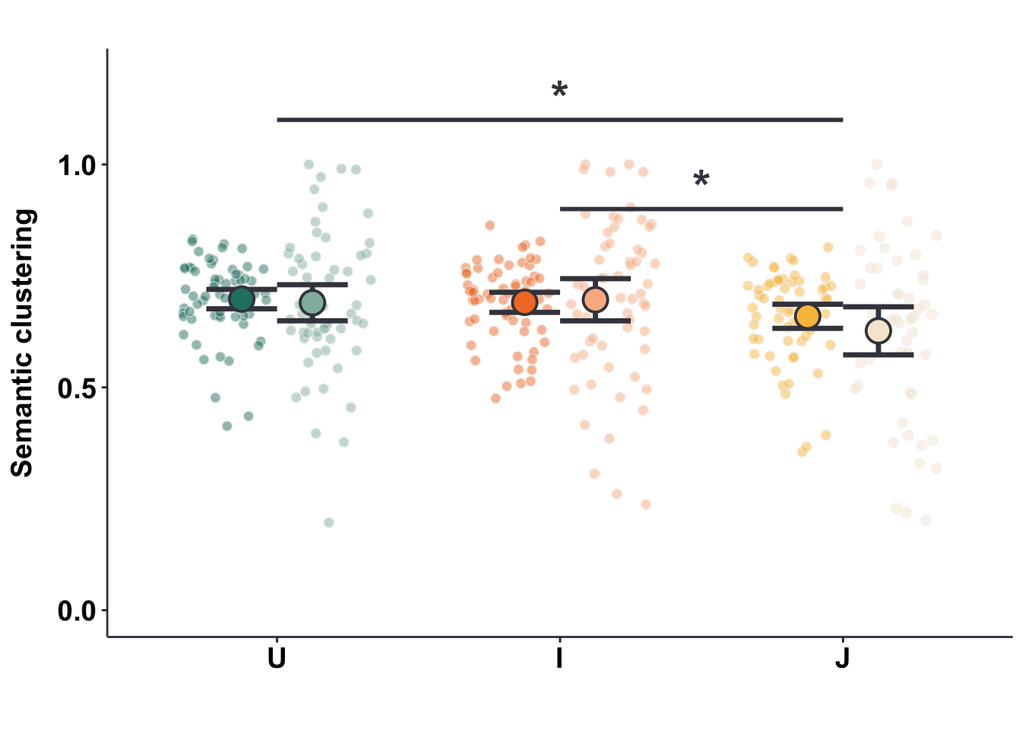

```r
esKnow1.semanticClustering.ann <- data.frame(xstart = c(1,2), xend = c(3,3),
                                             ystart = c(1.1, 0.9), yend = c(1.1, 0.9),
                                             x = c(2, 2.5),
                                             y = c(1.15, 0.95),
                                             labels = c("*", "*"))

esKnow1.semanticClustering_plot <- ggplot(esKnow1.clustering, aes(x = condition, y = semantic_clustering, fill = interaction(condition, event_condition), color = interaction(condition, event_condition)))+
  geom_jitter(alpha = jitter.alpha-.2, position = position_jitterdodge(1.2), size = jitter.size, shape = point.shape, color = jitter.outline)+
  stat_summary(geom = "errorbar", fun.data = "mean_cl_normal", width = 0.5, color = outline.color, alpha = errorbar.alpha, position =position_dodge(0.5), size = 1.2) +
  geom_point(stat = "summary", fun = "mean", size = point.size, shape = point.shape, color = outline.color, position = position_dodge(0.5), stroke = 1) +
  scale_fill_manual(values = colors$point.colors)+
  scale_color_manual(values = colors$point.colors)+
  scale_x_discrete(labels=c("Uninterrupted" = "U", "Interrupted" = "I",
                              "Jumbled" = "J"))+
  geom_segment(data = esKnow1.semanticClustering.ann, aes(x = xstart, y = ystart, xend = xend, yend = yend), color = outline.color, size = 1, inherit.aes = FALSE) +
  geom_text(data = esKnow1.semanticClustering.ann, aes(x = x, y = y, label = labels), color = outline.color, size = 8, fontface = txt.face, inherit.aes = FALSE)+
  # annotate("text", x = 2.5, y = 1.08, label = "***", color = outline.color, size = 8) +
  #geom_segment(aes(x = 1, y = .92, xend = 3, yend = .92), color = outline.color, size = 0.5) +
  #annotate("text", x = 2, y = .95, label = "*", color = outline.color, size = 8, fontface = txt.face) +
  coord_cartesian(ylim = c(0,1.2))+
  scale_y_continuous(breaks = c(0, 0.5, 1), labels = c('0.0', '0.5', '1.0'))+
  labs(y = "Semantic clustering", x = "", title = " ")+
  theme(legend.position = 'none') +
  theme.esKnow

esKnow1.semanticClustering_plot
```

```r
# setwd('../plots/')
# ggsave("esKnow1_semanticClustering_separated.pdf", plot = esKnow1.semanticClustering_plot, width = 5, height = 4, device = cairo_pdf)
# pdf_convert(pdf = "esKnow1_semanticClustering_separated.pdf", format = "png", dpi = 300,
#             filenames = "esKnow1_semanticClustering_separated.png")
```

**Lag CRP**

Build model

```r
lags_to_plot <- c(-5, -4, -3, -2, -1, 0,
                  1, 2, 3, 4, 5)

esKnow1.lagCRP$lag <- factor(esKnow1.lagCRP$lag, levels = lags_to_plot)
esKnow1.lagCRP$event_condition <- factor(esKnow1.lagCRP$event_condition, levels = c("intact", 'separated'))
esKnow1.lagCRP$condition <- factor(esKnow1.lagCRP$condition, levels = condition.factor)
esKnow1.lagCRP = complete(esKnow1.lagCRP, lag, nesting(pseudo_subid, condition, movName, event_condition, exp_subid), fill = list(conditional_probability = NA))

esKnow1.lagDiff.lmer <- lmer(conditional_probability~condition*lag*event_condition + movName + (1|exp_subid), data = esKnow1.lagCRP)
esKnow1.lagDiff.lmer.B <- lmer(conditional_probability~condition*lag*event_condition*movName + (1|exp_subid), data = esKnow1.lagCRP)
anova(esKnow1.lagDiff.lmer, esKnow1.lagDiff.lmer.B)
```

```
## Data: esKnow1.lagCRP
## Models:
## esKnow1.lagDiff.lmer: conditional_probability ~ condition * lag * event_condition + movName + (1 | exp_subid)
## esKnow1.lagDiff.lmer.B: conditional_probability ~ condition * lag * event_condition * movName + (1 | exp_subid)
##                        npar     AIC     BIC logLik deviance  Chisq Df
## esKnow1.lagDiff.lmer     63 -5067.7 -4675.8 2596.9  -5193.7
## esKnow1.lagDiff.lmer.B  122 -5174.8 -4415.8 2709.4  -5418.8 225.09 59
##                        Pr(>Chisq)
## esKnow1.lagDiff.lmer
## esKnow1.lagDiff.lmer.B  < 2.2e-16 ***
## ---
## Signif. codes:  0 '***' 0.001 '**' 0.01 '*' 0.05 '.' 0.1 ' ' 1
```

```r
emm_options(lmerTest.limit = 3800)
joint_tests(esKnow1.lagDiff.lmer.B)
```

```
##  model term                            df1     df2 F.ratio p.value
##  condition                               2 3115.08  32.512  <.0001
##  lag                                     9 3567.14 271.523  <.0001
##  event_condition                         1 3567.14   2.383  0.1228
##  movName                                 1 3579.12   1.813  0.1783
##  condition:lag                          18 3567.14   8.883  <.0001
##  condition:event_condition               2 3567.14   2.614  0.0734
##  condition:movName                       2 3567.14   1.533  0.2160
##  lag:event_condition                     9 3567.14   4.980  <.0001
##  lag:movName                             9 3567.14   1.077  0.3761
##  event_condition:movName                 1 3567.14   5.990  0.0144
##  condition:lag:event_condition          18 3567.14   1.713  0.0307
##  condition:lag:movName                  18 3567.14   1.944  0.0097
##  condition:event_condition:movName       2 3567.14   0.832  0.4351
##  lag:event_condition:movName             9 3567.14  16.548  <.0001
##  condition:lag:event_condition:movName  18 3567.14   1.113  0.3316
```

```r
eta_squared(esKnow1.lagDiff.lmer.B)
```

```
## # Effect Size for ANOVA (Type III)
##
## Parameter                             | Eta2 (partial) |       90% CI
## ---------------------------------------------------------------------
## condition                             |           0.02 | [0.01, 0.03]
## lag                                   |           0.41 | [0.39, 0.42]
## event_condition                       |       6.68e-04 | [0.00, 0.00]
## movName                               |       5.06e-04 | [0.00, 0.00]
## condition:lag                         |           0.04 | [0.03, 0.05]
## condition:event_condition             |       1.46e-03 | [0.00, 0.00]
## lag:event_condition                   |           0.01 | [0.01, 0.02]
## condition:movName                     |       8.56e-04 | [0.00, 0.00]
## lag:movName                           |       2.71e-03 | [0.00, 0.00]
## event_condition:movName               |       1.68e-03 | [0.00, 0.00]
## condition:lag:event_condition         |       8.57e-03 | [0.00, 0.01]
## condition:lag:movName                 |       9.72e-03 | [0.00, 0.01]
## condition:event_condition:movName     |       4.67e-04 | [0.00, 0.00]
## lag:event_condition:movName           |           0.04 | [0.03, 0.05]
## condition:lag:event_condition:movName |       5.59e-03 | [0.00, 0.00]
```

```r
joint_tests(esKnow1.lagDiff.lmer.B, by = "lag")
```

```
## lag = -5:
##  model term                        df1     df2 F.ratio p.value
##  condition                           2 3588.56   0.392  0.6759
##  event_condition                     1 3567.14   0.732  0.3923
##  movName                             1 3568.46   0.629  0.4279
##  condition:event_condition           2 3567.14   0.330  0.7187
##  condition:movName                   2 3567.14   0.383  0.6818
##  event_condition:movName             1 3567.14   0.838  0.3601
##  condition:event_condition:movName   2 3567.14   0.308  0.7351
##
## lag = -4:
##  model term                        df1     df2 F.ratio p.value
##  condition                           2 3588.56   0.015  0.9851
##  event_condition                     1 3567.14   0.071  0.7896
##  movName                             1 3568.46   0.684  0.4083
##  condition:event_condition           2 3567.14   0.055  0.9461
##  condition:movName                   2 3567.14   0.045  0.9559
##  event_condition:movName             1 3567.14   0.327  0.5674
##  condition:event_condition:movName   2 3567.14   0.029  0.9714
##
## lag = -3:
##  model term                        df1     df2 F.ratio p.value
##  condition                           2 3588.56   0.123  0.8842
##  event_condition                     1 3567.14   0.477  0.4898
##  movName                             1 3568.46   0.143  0.7051
##  condition:event_condition           2 3567.14   0.174  0.8406
##  condition:movName                   2 3567.14   0.526  0.5913
##  event_condition:movName             1 3567.14   0.117  0.7318
##  condition:event_condition:movName   2 3567.14   0.040  0.9605
##
## lag = -2:
##  model term                        df1     df2 F.ratio p.value
##  condition                           2 3588.56   0.814  0.4431
##  event_condition                     1 3567.14   0.256  0.6128
##  movName                             1 3568.46   0.495  0.4818
##  condition:event_condition           2 3567.14   1.332  0.2641
##  condition:movName                   2 3567.14   0.200  0.8188
##  event_condition:movName             1 3567.14   0.394  0.5302
##  condition:event_condition:movName   2 3567.14   1.016  0.3621
##
```

[output cut: 44 more lines]

```
##  movName                             1 3568.46   0.455  0.4998
##  condition:event_condition           2 3567.14   4.164  0.0156
##  condition:movName                   2 3567.14   2.194  0.1117
##  event_condition:movName             1 3567.14  11.426  0.0007
##  condition:event_condition:movName   2 3567.14   0.880  0.4147
##
## lag = 5:
##  model term                        df1     df2 F.ratio p.value
##  condition                           2 3588.56   0.112  0.8936
##  event_condition                     1 3567.14   3.415  0.0647
##  movName                             1 3568.46   0.451  0.5020
##  condition:event_condition           2 3567.14   0.429  0.6511
##  condition:movName                   2 3567.14   0.713  0.4902
##  event_condition:movName             1 3567.14   0.434  0.5103
##  condition:event_condition:movName   2 3567.14   0.066  0.9362
```

```r
eta_squared(esKnow1.lagDiff.lmer.B, by = "lag")
```

```
## # Effect Size for ANOVA (Type III)
##
## Parameter                             | Eta2 (partial) |       90% CI
## ---------------------------------------------------------------------
## condition                             |           0.02 | [0.01, 0.03]
## lag                                   |           0.41 | [0.39, 0.42]
## event_condition                       |       6.68e-04 | [0.00, 0.00]
## movName                               |       5.06e-04 | [0.00, 0.00]
## condition:lag                         |           0.04 | [0.03, 0.05]
## condition:event_condition             |       1.46e-03 | [0.00, 0.00]
## lag:event_condition                   |           0.01 | [0.01, 0.02]
## condition:movName                     |       8.56e-04 | [0.00, 0.00]
## lag:movName                           |       2.71e-03 | [0.00, 0.00]
## event_condition:movName               |       1.68e-03 | [0.00, 0.00]
## condition:lag:event_condition         |       8.57e-03 | [0.00, 0.01]
## condition:lag:movName                 |       9.72e-03 | [0.00, 0.01]
## condition:event_condition:movName     |       4.67e-04 | [0.00, 0.00]
## lag:event_condition:movName           |           0.04 | [0.03, 0.05]
## condition:lag:event_condition:movName |       5.59e-03 | [0.00, 0.00]
```

```r
summary(emmeans(esKnow1.lagDiff.lmer.B, "lag", contr = 'pairwise',weights = "proportional"), infer = TRUE)
```

```
## $emmeans
##  lag  emmean      SE   df lower.CL upper.CL t.ratio p.value
##  -5  0.00951 0.00618 1765 -0.00260   0.0216   1.540  0.1238
##  -4  0.00930 0.00618 1765 -0.00281   0.0214   1.506  0.1324
##  -3  0.01105 0.00618 1765 -0.00106   0.0232   1.790  0.0737
##  -2  0.02110 0.00618 1765  0.00899   0.0332   3.417  0.0006
##  -1  0.03942 0.00618 1765  0.02731   0.0515   6.384  <.0001
##  1   0.34432 0.00618 1765  0.33221   0.3564  55.755  <.0001
##  2   0.12499 0.00618 1765  0.11288   0.1371  20.240  <.0001
##  3   0.08286 0.00618 1765  0.07075   0.0950  13.417  <.0001
##  4   0.07073 0.00618 1765  0.05862   0.0828  11.453  <.0001
##  5   0.03418 0.00618 1765  0.02206   0.0463   5.534  <.0001
##
## Results are averaged over the levels of: condition, event_condition, movName
## Degrees-of-freedom method: kenward-roger
## Confidence level used: 0.95
##
## $contrasts
##  contrast     estimate     SE   df lower.CL  upper.CL t.ratio p.value
##  (-5) - (-4)  0.000212 0.0087 3567  -0.0273  0.027765   0.024  1.0000
##  (-5) - (-3) -0.001542 0.0087 3567  -0.0291  0.026011  -0.177  1.0000
##  (-5) - (-2) -0.011590 0.0087 3567  -0.0391  0.015963  -1.332  0.9464
##  (-5) - (-1) -0.029913 0.0087 3567  -0.0575 -0.002361  -3.437  0.0211
##  (-5) - 1    -0.334813 0.0087 3567  -0.3624 -0.307261 -38.469  <.0001
##  (-5) - 2    -0.115484 0.0087 3567  -0.1430 -0.087932 -13.269  <.0001
##  (-5) - 3    -0.073349 0.0087 3567  -0.1009 -0.045797  -8.428  <.0001
##  (-5) - 4    -0.061222 0.0087 3567  -0.0888 -0.033670  -7.034  <.0001
##  (-5) - 5    -0.024666 0.0087 3567  -0.0522  0.002886  -2.834  0.1255
##  (-4) - (-3) -0.001754 0.0087 3567  -0.0293  0.025799  -0.202  1.0000
##  (-4) - (-2) -0.011802 0.0087 3567  -0.0394  0.015751  -1.356  0.9402
##  (-4) - (-1) -0.030125 0.0087 3567  -0.0577 -0.002573  -3.461  0.0194
##  (-4) - 1    -0.335025 0.0087 3567  -0.3626 -0.307473 -38.493  <.0001
##  (-4) - 2    -0.115696 0.0087 3567  -0.1432 -0.088144 -13.293  <.0001
##  (-4) - 3    -0.073561 0.0087 3567  -0.1011 -0.046009  -8.452  <.0001
##  (-4) - 4    -0.061434 0.0087 3567  -0.0890 -0.033882  -7.059  <.0001
##  (-4) - 5    -0.024878 0.0087 3567  -0.0524  0.002674  -2.858  0.1179
##  (-3) - (-2) -0.010048 0.0087 3567  -0.0376  0.017504  -1.154  0.9788
##  (-3) - (-1) -0.028372 0.0087 3567  -0.0559 -0.000819  -3.260  0.0374
##  (-3) - 1    -0.333271 0.0087 3567  -0.3608 -0.305719 -38.292  <.0001
##  (-3) - 2    -0.113943 0.0087 3567  -0.1415 -0.086390 -13.092  <.0001
```

[output cut: 15 more lines]

```
##  1 - 3        0.261464 0.0087 3567   0.2339  0.289017  30.041  <.0001
##  1 - 4        0.273591 0.0087 3567   0.2460  0.301143  31.435  <.0001
##  1 - 5        0.310147 0.0087 3567   0.2826  0.337699  35.635  <.0001
##  2 - 3        0.042135 0.0087 3567   0.0146  0.069688   4.841  0.0001
##  2 - 4        0.054262 0.0087 3567   0.0267  0.081815   6.235  <.0001
##  2 - 5        0.090818 0.0087 3567   0.0633  0.118371  10.435  <.0001
##  3 - 4        0.012127 0.0087 3567  -0.0154  0.039679   1.393  0.9296
##  3 - 5        0.048683 0.0087 3567   0.0211  0.076235   5.594  <.0001
##  4 - 5        0.036556 0.0087 3567   0.0090  0.064108   4.200  0.0011
##
## Results are averaged over the levels of: condition, event_condition, movName
## Degrees-of-freedom method: kenward-roger
## Confidence level used: 0.95
## Conf-level adjustment: tukey method for comparing a family of 10 estimates
## P value adjustment: tukey method for comparing a family of 10 estimates
```

```r
summary(emmeans(esKnow1.lagDiff.lmer.B, "lag", contr = list(pos1vneg5 = c(-1,0,0,0,0,1,0,0,0,0),
                                                            pos1vneg4 = c(0,-1,0,0,0,1,0,0,0,0),
                                                            pos1vneg3 = c(0,0,-1,0,0,1,0,0,0,0),
                                                            pos1vneg2 = c(0,0,0,-1,0,1,0,0,0,0),
                                                            pos1vneg1 = c(0,0,0,0,-1,1,0,0,0,0),
                                                            pos1vpos2 = c(0,0,0,0,0,1,-1,0,0,0),
                                                            pos1vpos3 = c(0,0,0,0,0,1,0,-1,0,0),
                                                            pos1vpos4 = c(0,0,0,0,0,1,0,0,-1,0),
                                                            pos1vpos5 = c(0,0,0,0,0,1,0,0,0,-1)),weights = "proportional"), infer = TRUE)
```

```
## $emmeans
##  lag  emmean      SE   df lower.CL upper.CL t.ratio p.value
##  -5  0.00951 0.00618 1765 -0.00260   0.0216   1.540  0.1238
##  -4  0.00930 0.00618 1765 -0.00281   0.0214   1.506  0.1324
##  -3  0.01105 0.00618 1765 -0.00106   0.0232   1.790  0.0737
##  -2  0.02110 0.00618 1765  0.00899   0.0332   3.417  0.0006
##  -1  0.03942 0.00618 1765  0.02731   0.0515   6.384  <.0001
##  1   0.34432 0.00618 1765  0.33221   0.3564  55.755  <.0001
##  2   0.12499 0.00618 1765  0.11288   0.1371  20.240  <.0001
##  3   0.08286 0.00618 1765  0.07075   0.0950  13.417  <.0001
##  4   0.07073 0.00618 1765  0.05862   0.0828  11.453  <.0001
##  5   0.03418 0.00618 1765  0.02206   0.0463   5.534  <.0001
##
## Results are averaged over the levels of: condition, event_condition, movName
## Degrees-of-freedom method: kenward-roger
## Confidence level used: 0.95
##
## $contrasts
##  contrast  estimate     SE   df lower.CL upper.CL t.ratio p.value
##  pos1vneg5    0.335 0.0087 3567    0.318    0.352  38.469  <.0001
##  pos1vneg4    0.335 0.0087 3567    0.318    0.352  38.493  <.0001
##  pos1vneg3    0.333 0.0087 3567    0.316    0.350  38.292  <.0001
##  pos1vneg2    0.323 0.0087 3567    0.306    0.340  37.137  <.0001
##  pos1vneg1    0.305 0.0087 3567    0.288    0.322  35.032  <.0001
##  pos1vpos2    0.219 0.0087 3567    0.202    0.236  25.200  <.0001
##  pos1vpos3    0.261 0.0087 3567    0.244    0.279  30.041  <.0001
##  pos1vpos4    0.274 0.0087 3567    0.257    0.291  31.435  <.0001
##  pos1vpos5    0.310 0.0087 3567    0.293    0.327  35.635  <.0001
##
## Results are averaged over the levels of: condition, event_condition, movName
## Degrees-of-freedom method: kenward-roger
## Confidence level used: 0.95
```

```r
emm_options(lmerTest.limit = 3720)
lag.pairwise.emm <- emmeans(esKnow1.lagDiff.lmer.B, "condition", by = c("lag"), contr = "pairwise", weights = "proportional", adjust = "holm")
confint(lag.pairwise.emm, adjust = "holm", level = .95)
```

```
## $emmeans
## lag = -5:
##  condition      emmean     SE   df lower.CL upper.CL
##  Uninterrupted 0.00734 0.0105 3287 -0.01782   0.0325
##  Interrupted   0.00423 0.0107 3299 -0.02134   0.0298
##  Jumbled       0.01703 0.0109 3290 -0.00896   0.0430
##
## lag = -4:
##  condition      emmean     SE   df lower.CL upper.CL
##  Uninterrupted 0.01071 0.0105 3287 -0.01446   0.0359
##  Interrupted   0.00904 0.0107 3299 -0.01653   0.0346
##  Jumbled       0.00808 0.0109 3290 -0.01791   0.0341
##
## lag = -3:
##  condition      emmean     SE   df lower.CL upper.CL
##  Uninterrupted 0.01421 0.0105 3287 -0.01095   0.0394
##  Interrupted   0.00687 0.0107 3299 -0.01870   0.0324
##  Jumbled       0.01218 0.0109 3290 -0.01381   0.0382
##
## lag = -2:
##  condition      emmean     SE   df lower.CL upper.CL
##  Uninterrupted 0.01382 0.0105 3287 -0.01134   0.0390
##  Interrupted   0.03197 0.0107 3299  0.00640   0.0575
##  Jumbled       0.01780 0.0109 3290 -0.00819   0.0438
##
## lag = -1:
##  condition      emmean     SE   df lower.CL upper.CL
##  Uninterrupted 0.02978 0.0105 3287  0.00462   0.0549
##  Interrupted   0.05296 0.0107 3299  0.02739   0.0785
##  Jumbled       0.03556 0.0109 3290  0.00957   0.0616
##
## lag = 1:
##  condition      emmean     SE   df lower.CL upper.CL
##  Uninterrupted 0.41415 0.0105 3287  0.38899   0.4393
##  Interrupted   0.38278 0.0107 3299  0.35721   0.4083
##  Jumbled       0.23126 0.0109 3290  0.20527   0.2573
##
## lag = 2:
##  condition      emmean     SE   df lower.CL upper.CL
##  Uninterrupted 0.14503 0.0105 3287  0.11986   0.1702
```

[output cut: 76 more lines]

```
##  contrast                     estimate     SE   df lower.CL upper.CL
##  Uninterrupted - Interrupted  0.004263 0.0150 3589 -0.03157   0.0401
##  Uninterrupted - Jumbled      0.044822 0.0151 3592  0.00868   0.0810
##  Interrupted - Jumbled        0.040559 0.0152 3589  0.00414   0.0770
##
## lag = 5:
##  contrast                     estimate     SE   df lower.CL upper.CL
##  Uninterrupted - Interrupted  0.000486 0.0150 3589 -0.03535   0.0363
##  Uninterrupted - Jumbled      0.006416 0.0151 3592 -0.02972   0.0426
##  Interrupted - Jumbled        0.005930 0.0152 3589 -0.03049   0.0424
##
## Results are averaged over the levels of: event_condition, movName
## Degrees-of-freedom method: kenward-roger
## Confidence level used: 0.95
## Conf-level adjustment: bonferroni method for 3 estimates
```

```r
summary(lag.pairwise.emm, infer = TRUE)
```

```
## $emmeans
## lag = -5:
##  condition      emmean     SE   df lower.CL upper.CL t.ratio p.value
##  Uninterrupted 0.00734 0.0105 3287 -0.01326   0.0279   0.699  0.4846
##  Interrupted   0.00423 0.0107 3299 -0.01670   0.0252   0.397  0.6917
##  Jumbled       0.01703 0.0109 3290 -0.00424   0.0383   1.570  0.1166
##
## lag = -4:
##  condition      emmean     SE   df lower.CL upper.CL t.ratio p.value
##  Uninterrupted 0.01071 0.0105 3287 -0.00989   0.0313   1.019  0.3082
##  Interrupted   0.00904 0.0107 3299 -0.01189   0.0300   0.847  0.3973
##  Jumbled       0.00808 0.0109 3290 -0.01319   0.0294   0.745  0.4565
##
## lag = -3:
##  condition      emmean     SE   df lower.CL upper.CL t.ratio p.value
##  Uninterrupted 0.01421 0.0105 3287 -0.00639   0.0348   1.353  0.1763
##  Interrupted   0.00687 0.0107 3299 -0.01406   0.0278   0.644  0.5197
##  Jumbled       0.01218 0.0109 3290 -0.00910   0.0335   1.122  0.2618
##
## lag = -2:
##  condition      emmean     SE   df lower.CL upper.CL t.ratio p.value
##  Uninterrupted 0.01382 0.0105 3287 -0.00678   0.0344   1.316  0.1884
##  Interrupted   0.03197 0.0107 3299  0.01104   0.0529   2.994  0.0028
##  Jumbled       0.01780 0.0109 3290 -0.00348   0.0391   1.640  0.1010
##
## lag = -1:
##  condition      emmean     SE   df lower.CL upper.CL t.ratio p.value
##  Uninterrupted 0.02978 0.0105 3287  0.00918   0.0504   2.835  0.0046
##  Interrupted   0.05296 0.0107 3299  0.03203   0.0739   4.961  <.0001
##  Jumbled       0.03556 0.0109 3290  0.01429   0.0568   3.277  0.0011
##
## lag = 1:
##  condition      emmean     SE   df lower.CL upper.CL t.ratio p.value
##  Uninterrupted 0.41415 0.0105 3287  0.39355   0.4347  39.420  <.0001
##  Interrupted   0.38278 0.0107 3299  0.36185   0.4037  35.854  <.0001
##  Jumbled       0.23126 0.0109 3290  0.20998   0.2525  21.311  <.0001
##
## lag = 2:
##  condition      emmean     SE   df lower.CL upper.CL t.ratio p.value
##  Uninterrupted 0.14503 0.0105 3287  0.12443   0.1656  13.804  <.0001
```

[output cut: 116 more lines]

```
## lag = 5:
##  contrast                     estimate     SE   df lower.CL upper.CL t.ratio
##  Uninterrupted - Interrupted  0.000486 0.0150 3589 -0.03535   0.0363   0.032
##  Uninterrupted - Jumbled      0.006416 0.0151 3592 -0.02972   0.0426   0.425
##  Interrupted - Jumbled        0.005930 0.0152 3589 -0.03049   0.0424   0.390
##  p.value
##   1.0000
##   1.0000
##   1.0000
##
## Results are averaged over the levels of: event_condition, movName
## Degrees-of-freedom method: kenward-roger
## Confidence level used: 0.95
## Conf-level adjustment: bonferroni method for 3 estimates
## P value adjustment: holm method for 3 tests
```

```r
summary(emmeans(esKnow1.lagDiff.lmer, "condition", by = c("event_condition","lag"), contr = "pairwise", weights = "proportional", adjust = "holm")$contrasts, infer = TRUE)
```

```
## event_condition = intact, lag = -5:
##  contrast                     estimate     SE   df lower.CL upper.CL t.ratio
##  Uninterrupted - Interrupted -0.003495 0.0216 3638 -0.05530   0.0483  -0.162
##  Uninterrupted - Jumbled     -0.004088 0.0218 3641 -0.05633   0.0482  -0.187
##  Interrupted - Jumbled       -0.000593 0.0220 3639 -0.05325   0.0521  -0.027
##  p.value
##   1.0000
##   1.0000
##   1.0000
##
## event_condition = separated, lag = -5:
##  contrast                     estimate     SE   df lower.CL upper.CL t.ratio
##  Uninterrupted - Interrupted  0.009890 0.0216 3638 -0.04192   0.0617   0.457
##  Uninterrupted - Jumbled     -0.015324 0.0218 3641 -0.06757   0.0369  -0.703
##  Interrupted - Jumbled       -0.025214 0.0220 3639 -0.07787   0.0274  -1.147
##  p.value
##   0.9648
##   0.9648
##   0.7544
##
## event_condition = intact, lag = -4:
##  contrast                     estimate     SE   df lower.CL upper.CL t.ratio
##  Uninterrupted - Interrupted -0.001936 0.0216 3638 -0.05374   0.0499  -0.090
##  Uninterrupted - Jumbled      0.003870 0.0218 3641 -0.04838   0.0561   0.177
##  Interrupted - Jumbled        0.005806 0.0220 3639 -0.04685   0.0585   0.264
##  p.value
##   1.0000
##   1.0000
##   1.0000
##
## event_condition = separated, lag = -4:
##  contrast                     estimate     SE   df lower.CL upper.CL t.ratio
##  Uninterrupted - Interrupted  0.005051 0.0216 3638 -0.04676   0.0569   0.234
##  Uninterrupted - Jumbled      0.001342 0.0218 3641 -0.05090   0.0536   0.062
##  Interrupted - Jumbled       -0.003709 0.0220 3639 -0.05636   0.0489  -0.169
##  p.value
##   1.0000
##   1.0000
##   1.0000
##
```

[output cut: 150 more lines]

```
## event_condition = separated, lag = 5:
##  contrast                     estimate     SE   df lower.CL upper.CL t.ratio
##  Uninterrupted - Interrupted  0.003775 0.0216 3638 -0.04803   0.0556   0.175
##  Uninterrupted - Jumbled     -0.003596 0.0218 3641 -0.05584   0.0487  -0.165
##  Interrupted - Jumbled       -0.007371 0.0220 3639 -0.06002   0.0453  -0.335
##  p.value
##   1.0000
##   1.0000
##   1.0000
##
## Results are averaged over the levels of: movName
## Degrees-of-freedom method: kenward-roger
## Confidence level used: 0.95
## Conf-level adjustment: bonferroni method for 3 estimates
## P value adjustment: holm method for 3 tests
```

```r
summary(emmeans(esKnow1.lagDiff.lmer.B, c("condition"), by = c("lag", "event_condition"), contr = "pairwise", weights = "proportional", adjust = "holm")$contrasts, infer = TRUE)
```

```
## lag = -5, event_condition = intact:
##  contrast                     estimate     SE   df lower.CL upper.CL t.ratio
##  Uninterrupted - Interrupted -0.003527 0.0212 3579 -0.05420   0.0471  -0.167
##  Uninterrupted - Jumbled     -0.004117 0.0213 3582 -0.05522   0.0470  -0.193
##  Interrupted - Jumbled       -0.000591 0.0215 3580 -0.05209   0.0509  -0.027
##  p.value
##   1.0000
##   1.0000
##   1.0000
##
## lag = -4, event_condition = intact:
##  contrast                     estimate     SE   df lower.CL upper.CL t.ratio
##  Uninterrupted - Interrupted -0.001954 0.0212 3579 -0.05263   0.0487  -0.092
##  Uninterrupted - Jumbled      0.003850 0.0213 3582 -0.04725   0.0549   0.180
##  Interrupted - Jumbled        0.005804 0.0215 3580 -0.04570   0.0573   0.270
##  p.value
##   1.0000
##   1.0000
##   1.0000
##
## lag = -3, event_condition = intact:
##  contrast                     estimate     SE   df lower.CL upper.CL t.ratio
##  Uninterrupted - Interrupted  0.007509 0.0212 3579 -0.04317   0.0582   0.355
##  Uninterrupted - Jumbled      0.009861 0.0213 3582 -0.04124   0.0610   0.462
##  Interrupted - Jumbled        0.002352 0.0215 3580 -0.04915   0.0539   0.109
##  p.value
##   1.0000
##   1.0000
##   1.0000
##
## lag = -2, event_condition = intact:
##  contrast                     estimate     SE   df lower.CL upper.CL t.ratio
##  Uninterrupted - Interrupted  0.000629 0.0212 3579 -0.05004   0.0513   0.030
##  Uninterrupted - Jumbled     -0.008211 0.0213 3582 -0.05931   0.0429  -0.385
##  Interrupted - Jumbled       -0.008841 0.0215 3580 -0.06034   0.0427  -0.411
##  p.value
##   1.0000
##   1.0000
##   1.0000
##
```

[output cut: 150 more lines]

```
## lag = 5, event_condition = separated:
##  contrast                     estimate     SE   df lower.CL upper.CL t.ratio
##  Uninterrupted - Interrupted  0.003801 0.0212 3579 -0.04687   0.0545   0.180
##  Uninterrupted - Jumbled     -0.003770 0.0213 3582 -0.05487   0.0473  -0.177
##  Interrupted - Jumbled       -0.007571 0.0215 3580 -0.05907   0.0439  -0.352
##  p.value
##   1.0000
##   1.0000
##   1.0000
##
## Results are averaged over the levels of: movName
## Degrees-of-freedom method: kenward-roger
## Confidence level used: 0.95
## Conf-level adjustment: bonferroni method for 3 estimates
## P value adjustment: holm method for 3 tests
```

```r
test(contrast(emmeans(esKnow1.lagDiff.lmer.B, c("condition", "event_condition"), by = "lag", weights = "proportional", adjust = "holm"), interaction = "consec"), joint = TRUE)
```

```
##  lag df1     df2 F.ratio p.value
##  -5    2 3567.14   0.324  0.7235
##  -4    2 3567.14   0.055  0.9461
##  -3    2 3567.14   0.173  0.8411
##  -2    2 3567.14   1.311  0.2697
##  -1    2 3567.14   0.014  0.9857
##  1     2 3567.14   8.873  0.0001
##  2     2 3567.14   0.078  0.9249
##  3     2 3567.14   2.547  0.0784
##  4     2 3567.14   4.167  0.0156
##  5     2 3567.14   0.427  0.6523
```

```r
summary(emmeans(esKnow1.lagDiff.lmer.B, c("event_condition", "lag"), by = "condition"))
```

```
## condition = Uninterrupted:
##  event_condition lag  emmean     SE   df  lower.CL upper.CL
##  intact          -5  0.00178 0.0148 3559 -2.73e-02   0.0309
##  separated       -5  0.01305 0.0148 3559 -1.61e-02   0.0422
##  intact          -4  0.00820 0.0148 3559 -2.09e-02   0.0373
##  separated       -4  0.01305 0.0148 3559 -1.61e-02   0.0422
##  intact          -3  0.01253 0.0148 3559 -1.66e-02   0.0416
##  separated       -3  0.01565 0.0148 3559 -1.35e-02   0.0448
##  intact          -2  0.02189 0.0148 3559 -7.22e-03   0.0510
##  separated       -2  0.00575 0.0148 3559 -2.34e-02   0.0349
##  intact          -1  0.03556 0.0148 3559  6.45e-03   0.0647
##  separated       -1  0.02398 0.0148 3559 -5.13e-03   0.0531
##  intact          1   0.38146 0.0148 3559  3.52e-01   0.4106
##  separated       1   0.44586 0.0148 3559  4.17e-01   0.4750
##  intact          2   0.17994 0.0148 3559  1.51e-01   0.2090
##  separated       2   0.10956 0.0148 3559  8.04e-02   0.1387
##  intact          3   0.09596 0.0148 3559  6.69e-02   0.1251
##  separated       3   0.09410 0.0148 3559  6.50e-02   0.1232
##  intact          4   0.06337 0.0148 3559  3.43e-02   0.0925
##  separated       4   0.10985 0.0148 3559  8.07e-02   0.1390
##  intact          5   0.05012 0.0148 3559  2.10e-02   0.0792
##  separated       5   0.02283 0.0148 3559 -6.28e-03   0.0519
##
## condition = Interrupted:
##  event_condition lag  emmean     SE   df  lower.CL upper.CL
##  intact          -5  0.00529 0.0151 3562 -2.43e-02   0.0349
##  separated       -5  0.00313 0.0151 3562 -2.65e-02   0.0327
##  intact          -4  0.01017 0.0151 3562 -1.94e-02   0.0398
##  separated       -4  0.00781 0.0151 3562 -2.18e-02   0.0374
##  intact          -3  0.00513 0.0151 3562 -2.45e-02   0.0347
##  separated       -3  0.00868 0.0151 3562 -2.09e-02   0.0383
##  intact          -2  0.02113 0.0151 3562 -8.46e-03   0.0507
##  separated       -2  0.04300 0.0151 3562  1.34e-02   0.0726
##  intact          -1  0.05867 0.0151 3562  2.91e-02   0.0883
##  separated       -1  0.04714 0.0151 3562  1.75e-02   0.0767
##  intact          1   0.35549 0.0151 3562  3.26e-01   0.3851
##  separated       1   0.41058 0.0151 3562  3.81e-01   0.4402
##  intact          2   0.18550 0.0151 3562  1.56e-01   0.2151
##  separated       2   0.11241 0.0151 3562  8.28e-02   0.1420
##  intact          3   0.08050 0.0151 3562  5.09e-02   0.1101
```

[output cut: 17 more lines]

```
##  separated       -1  0.02771 0.0153 3560 -2.36e-03   0.0578
##  intact          1   0.25671 0.0153 3560  2.27e-01   0.2868
##  separated       1   0.20562 0.0153 3560  1.76e-01   0.2357
##  intact          2   0.11997 0.0153 3560  8.99e-02   0.1500
##  separated       2   0.03872 0.0153 3560  8.65e-03   0.0688
##  intact          3   0.05447 0.0153 3560  2.44e-02   0.0845
##  separated       3   0.03844 0.0153 3560  8.37e-03   0.0685
##  intact          4   0.06166 0.0153 3560  3.16e-02   0.0917
##  separated       4   0.02146 0.0153 3560 -8.61e-03   0.0515
##  intact          5   0.03340 0.0153 3560  3.34e-03   0.0635
##  separated       5   0.02646 0.0153 3560 -3.61e-03   0.0565
##
## Results are averaged over the levels of: movName
## Degrees-of-freedom method: kenward-roger
## Confidence level used: 0.95
```

```r
summary(emmeans(esKnow1.lagDiff.lmer.B, c("event_condition", "lag"), by = "condition", contr = list(c1 = c(0,0,
  0,0,
  0,0,
  0,0,
  0,0,
  1, -1,
  0,0,
  0,0,
  0,0,
  0,0)), adjust = "holm")$contrasts, infer = T)
```

```
## condition = Uninterrupted:
##  contrast estimate     SE   df lower.CL upper.CL t.ratio p.value
##  c1        -0.0644 0.0210 3567  -0.1055  -0.0233  -3.069  0.0022
##
## condition = Interrupted:
##  contrast estimate     SE   df lower.CL upper.CL t.ratio p.value
##  c1        -0.0551 0.0213 3567  -0.0969  -0.0133  -2.583  0.0098
##
## condition = Jumbled:
##  contrast estimate     SE   df lower.CL upper.CL t.ratio p.value
##  c1         0.0511 0.0217 3567   0.0086   0.0936   2.357  0.0185
##
## Results are averaged over the levels of: movName
## Degrees-of-freedom method: kenward-roger
## Confidence level used: 0.95
```

(intact - separated)lag1 Uninterrupted - Interrupted

```r
summary(emmeans(esKnow1.lagDiff.lmer.B, c("event_condition", "lag", "condition"), contr = list(c1 = c(0,0,
  0,0,
  0,0,
  0,0,
  0,0,
  1, -1,
  0,0,
  0,0,
  0,0,
  0,0,
  0,0,
  0,0,
  0,0,
  0,0,
  0,0,
  -1, 1,
  0,0,
  0,0,
  0,0,
  0,0,
  0,0,
  0,0,
  0,0,
  0,0,
  0,0,
  0,0,
  0,0,
  0,0,
  0,0,
  0,0)), adjust = "holm")$contrasts, infer = T)
```

```
##  contrast estimate     SE   df lower.CL upper.CL t.ratio p.value
##  c1       -0.00931 0.0299 3567   -0.068   0.0494  -0.311  0.7557
##
## Results are averaged over the levels of: movName
## Degrees-of-freedom method: kenward-roger
## Confidence level used: 0.95
```

```r
summary(emmeans(esKnow1.lagDiff.lmer.B, c("event_condition", "lag", "condition")))
```

```
##  event_condition lag condition      emmean     SE   df  lower.CL upper.CL
##  intact          -5  Uninterrupted 0.00178 0.0148 3559 -2.73e-02   0.0309
##  separated       -5  Uninterrupted 0.01305 0.0148 3559 -1.61e-02   0.0422
##  intact          -4  Uninterrupted 0.00820 0.0148 3559 -2.09e-02   0.0373
##  separated       -4  Uninterrupted 0.01305 0.0148 3559 -1.61e-02   0.0422
##  intact          -3  Uninterrupted 0.01253 0.0148 3559 -1.66e-02   0.0416
##  separated       -3  Uninterrupted 0.01565 0.0148 3559 -1.35e-02   0.0448
##  intact          -2  Uninterrupted 0.02189 0.0148 3559 -7.22e-03   0.0510
##  separated       -2  Uninterrupted 0.00575 0.0148 3559 -2.34e-02   0.0349
##  intact          -1  Uninterrupted 0.03556 0.0148 3559  6.45e-03   0.0647
##  separated       -1  Uninterrupted 0.02398 0.0148 3559 -5.13e-03   0.0531
##  intact          1   Uninterrupted 0.38146 0.0148 3559  3.52e-01   0.4106
##  separated       1   Uninterrupted 0.44586 0.0148 3559  4.17e-01   0.4750
##  intact          2   Uninterrupted 0.17994 0.0148 3559  1.51e-01   0.2090
##  separated       2   Uninterrupted 0.10956 0.0148 3559  8.04e-02   0.1387
##  intact          3   Uninterrupted 0.09596 0.0148 3559  6.69e-02   0.1251
##  separated       3   Uninterrupted 0.09410 0.0148 3559  6.50e-02   0.1232
##  intact          4   Uninterrupted 0.06337 0.0148 3559  3.43e-02   0.0925
##  separated       4   Uninterrupted 0.10985 0.0148 3559  8.07e-02   0.1390
##  intact          5   Uninterrupted 0.05012 0.0148 3559  2.10e-02   0.0792
##  separated       5   Uninterrupted 0.02283 0.0148 3559 -6.28e-03   0.0519
##  intact          -5  Interrupted   0.00529 0.0151 3562 -2.43e-02   0.0349
##  separated       -5  Interrupted   0.00313 0.0151 3562 -2.65e-02   0.0327
##  intact          -4  Interrupted   0.01017 0.0151 3562 -1.94e-02   0.0398
##  separated       -4  Interrupted   0.00781 0.0151 3562 -2.18e-02   0.0374
##  intact          -3  Interrupted   0.00513 0.0151 3562 -2.45e-02   0.0347
##  separated       -3  Interrupted   0.00868 0.0151 3562 -2.09e-02   0.0383
##  intact          -2  Interrupted   0.02113 0.0151 3562 -8.46e-03   0.0507
##  separated       -2  Interrupted   0.04300 0.0151 3562  1.34e-02   0.0726
##  intact          -1  Interrupted   0.05867 0.0151 3562  2.91e-02   0.0883
##  separated       -1  Interrupted   0.04714 0.0151 3562  1.75e-02   0.0767
##  intact          1   Interrupted   0.35549 0.0151 3562  3.26e-01   0.3851
##  separated       1   Interrupted   0.41058 0.0151 3562  3.81e-01   0.4402
##  intact          2   Interrupted   0.18550 0.0151 3562  1.56e-01   0.2151
##  separated       2   Interrupted   0.11241 0.0151 3562  8.28e-02   0.1420
##  intact          3   Interrupted   0.08050 0.0151 3562  5.09e-02   0.1101
##  separated       3   Interrupted   0.12938 0.0151 3562  9.98e-02   0.1590
##  intact          4   Interrupted   0.08320 0.0151 3562  5.36e-02   0.1128
##  separated       4   Interrupted   0.08083 0.0151 3562  5.12e-02   0.1104
##  intact          5   Interrupted   0.05282 0.0151 3562  2.32e-02   0.0824
```

[output cut: 10 more lines]

```
##  separated       -1  Jumbled       0.02771 0.0153 3560 -2.36e-03   0.0578
##  intact          1   Jumbled       0.25671 0.0153 3560  2.27e-01   0.2868
##  separated       1   Jumbled       0.20562 0.0153 3560  1.76e-01   0.2357
##  intact          2   Jumbled       0.11997 0.0153 3560  8.99e-02   0.1500
##  separated       2   Jumbled       0.03872 0.0153 3560  8.65e-03   0.0688
##  intact          3   Jumbled       0.05447 0.0153 3560  2.44e-02   0.0845
##  separated       3   Jumbled       0.03844 0.0153 3560  8.37e-03   0.0685
##  intact          4   Jumbled       0.06166 0.0153 3560  3.16e-02   0.0917
##  separated       4   Jumbled       0.02146 0.0153 3560 -8.61e-03   0.0515
##  intact          5   Jumbled       0.03340 0.0153 3560  3.34e-03   0.0635
##  separated       5   Jumbled       0.02646 0.0153 3560 -3.61e-03   0.0565
##
## Results are averaged over the levels of: movName
## Degrees-of-freedom method: kenward-roger
## Confidence level used: 0.95
```

(intact - separated)lag1 Uninterrupted & Interrupted - Jumbled

```r
summary(emmeans(esKnow1.lagDiff.lmer.B, c("event_condition", "lag", "condition"),
                contr = list(lag1 = c(0,0,0,0,0,0,0,0,0,0,.5, -.5,0,0,0,0,0,0,0,0,
                                      0,0,0,0,0,0,0,0,0,0,.5, -.5,0,0,0,0,0,0,0,0,
                                      0,0,0,0,0,0,0,0,0,0,-1,1,0,0,0,0,0,0,0,0),
                             lag2 = c(0,0,0,0,0,0,0,0,0,0,0,0,.5,-.5,0,0,0,0,0,0,
                                      0,0,0,0,0,0,0,0,0,0,0,0,.5,-.5,0,0,0,0,0,0,
                                      0,0,0,0,0,0,0,0,0,0,0,0,-1,1,0,0,0,0,0,0),
                             lag3 = c(0,0,0,0,0,0,0,0,0,0,0,0,0,0,.5,-.5,0,0,0,0,
                                      0,0,0,0,0,0,0,0,0,0,0,0,0,0,.5,-.5,0,0,0,0,
                                      0,0,0,0,0,0,0,0,0,0,0,0,0,0,-1,1,0,0,0,0),
                             lag4 = c(0,0,0,0,0,0,0,0,0,0,0,0,0,0,0,0,.5,-.5,0,0,
                                      0,0,0,0,0,0,0,0,0,0,0,0,0,0,0,0,.5,-.5,0,0,
                                      0,0,0,0,0,0,0,0,0,0,0,0,0,0,0,0,-1,1,0,0),
                             lag5 = c(0,0,0,0,0,0,0,0,0,0,0,0,0,0,0,0,0,0,.5,-.5,
                                      0,0,0,0,0,0,0,0,0,0,0,0,0,0,0,0,0,0,.5,-.5,
                                      0,0,0,0,0,0,0,0,0,0,0,0,0,0,0,0,0,0,-1,1)), adjust = "holm")$contrasts, infer = T)
```

```
##  contrast estimate     SE   df lower.CL upper.CL t.ratio p.value
##  lag1     -0.11083 0.0263 3567  -0.1787 -0.04296  -4.209  0.0001
##  lag2     -0.00952 0.0263 3567  -0.0774  0.05835  -0.361  0.7356
##  lag3     -0.03954 0.0263 3567  -0.1074  0.02833  -1.501  0.4000
##  lag4     -0.06226 0.0263 3567  -0.1301  0.00561  -2.364  0.0725
##  lag5      0.02372 0.0263 3567  -0.0441  0.09159   0.901  0.7356
##
## Results are averaged over the levels of: movName
## Degrees-of-freedom method: kenward-roger
## Confidence level used: 0.95
## Conf-level adjustment: bonferroni method for 5 estimates
## P value adjustment: holm method for 5 tests
```

Analyze difference between U&I vs J for all lags in intact and separated conditions

```r
summary(emmeans(esKnow1.lagDiff.lmer.B, c( "condition", "lag"), by = "event_condition", contr = list(lag_neg1 = c(0,0,0,
  0,0,0,
  0,0,0,
  0,0,0,
  .5,.5, -1,
  0,0,0,
  0,0,0,
  0,0,0,
  0,0,0,
  0,0,0),
  lag_pos1 = c(0,0,0,
  0,0,0,
  0,0,0,
  0,0,0,
  0,0,0,
  .5,.5, -1,
  0,0,0,
  0,0,0,
  0,0,0,
  0,0,0),
  lag_pos2 = c(0,0,0,
  0,0,0,
  0,0,0,
  0,0,0,
  0,0,0,
  0,0,0,
  .5,.5, -1,
  0,0,0,
  0,0,0,
  0,0,0),
  lag_pos3 = c(0,0,0,
  0,0,0,
  0,0,0,
  0,0,0,
  0,0,0,
  0,0,0,
  0,0,0,
  .5,.5, -1,
  0,0,0,
  0,0,0),
  lag_pos4 = c(0,0,0,
  0,0,0,
  0,0,0,
  0,0,0,
  0,0,0,
  0,0,0,
  0,0,0,
  0,0,0,
  .5,.5, -1,
  0,0,0)), adjust = "holm")$contrasts, infer = T)
```

```
## event_condition = intact:
##  contrast estimate     SE   df lower.CL upper.CL t.ratio p.value
##  lag_neg1  0.00359 0.0186 3581  -0.0444   0.0516   0.193  1.0000
##  lag_pos1  0.11177 0.0186 3581   0.0638   0.1598   6.001  <.0001
##  lag_pos2  0.06275 0.0186 3581   0.0148   0.1107   3.369  0.0030
##  lag_pos3  0.03376 0.0186 3581  -0.0142   0.0818   1.813  0.2098
##  lag_pos4  0.01163 0.0186 3581  -0.0364   0.0596   0.624  1.0000
##
## event_condition = separated:
##  contrast estimate     SE   df lower.CL upper.CL t.ratio p.value
##  lag_neg1  0.00785 0.0186 3581  -0.0401   0.0559   0.422  0.6733
##  lag_pos1  0.22260 0.0186 3581   0.1746   0.2706  11.952  <.0001
##  lag_pos2  0.07227 0.0186 3581   0.0243   0.1203   3.880  0.0003
##  lag_pos3  0.07330 0.0186 3581   0.0253   0.1213   3.936  0.0003
##  lag_pos4  0.07388 0.0186 3581   0.0259   0.1219   3.967  0.0003
##
## Results are averaged over the levels of: movName
## Degrees-of-freedom method: kenward-roger
## Confidence level used: 0.95
## Conf-level adjustment: bonferroni method for 5 estimates
## P value adjustment: holm method for 5 tests
```

No difference between condition in the negative lags (backward recall tendency), suggesting that participants in all condition tend to recall in the forward direction. However, the tendency to consecutively recall events in the forward direction is lower in Jumbled - suggesting that Jumbled participants are less likely to recall events in sequence. +1 lag for interrupted is also lower compared to Uninterrupted.

Get marginal means and confidence interval for each condition for plotting

```r
conf <- summary(emmeans(esKnow1.lagDiff.lmer.B, c("lag","condition", "event_condition")), infer = TRUE)
conf$lag <- factor(conf$lag, levels = lags_to_plot)
conf = complete(conf, lag, nesting(condition, event_condition))
```

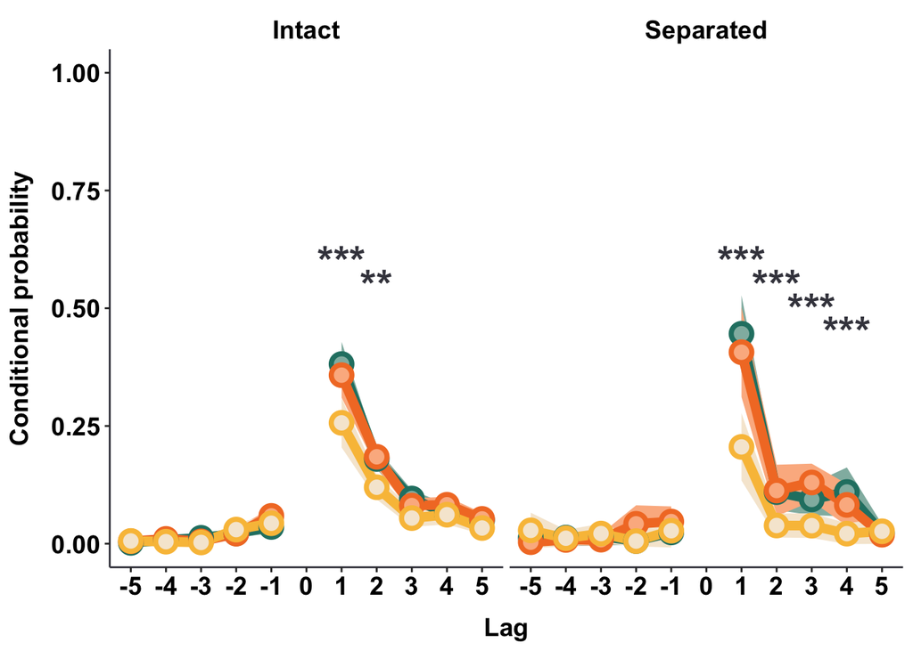

```r
esKnow1.lagCRP_plot <- esKnow1.lagCRP %>% dplyr::group_by(lag, condition, event_condition) %>% dplyr::summarise(mean.prob = mean(conditional_probability), se.prob = sd(conditional_probability)/sqrt(n()), n.prob = n()) %>% dplyr::mutate(
         lower.ci.prob = mean.prob - qt(1 - (0.05 / 2), n.prob - 1) * se.prob,
         upper.ci.prob = mean.prob + qt(1 - (0.05 / 2), n.prob - 1) * se.prob)
esKnow1.lagCRP_plot$lower.ci <- conf$lower.CL
esKnow1.lagCRP_plot$upper.ci <- conf$upper.CL

#create table for significance markings
lagCRP_ann <- data.frame(lag = factor(c(1,2,1,2,3,4), levels = lags_to_plot),
                         y = c(.6, .55, .6, .55, .5, .45),
                         event_condition = factor(c('intact', 'intact', 'separated', 'separated', 'separated', 'separated'), levels = c('intact', 'separated')),
                         labels = c('***', '**', '***', '***', '***', '***'))

esKnow1_lagCRP_plot <- ggplot(esKnow1.lagCRP_plot[!is.na(esKnow1.lagCRP_plot$condition),], aes(x = lag, y = mean.prob, group = condition, color = condition))+
    geom_ribbon(aes(ymin = lower.ci.prob, ymax = upper.ci.prob, fill = condition), color = NA, alpha = 1)+
    geom_line(size = 2.5)+
    geom_point( alpha = 1.2, shape = 21, size = point.size - 1, stroke = 2, show.legend = FALSE, aes(fill = condition))+
    #stat_summary(geom = "errorbar", fun.data = "mean_se", width = 0.2, alpha = 1, size = 0.7)+
    scale_fill_manual(values = colors$point.colors[4:6], labels = c('U', 'I', 'J'))+
    scale_color_manual(values = colors$point.colors, labels= c('U', 'I', 'J'))+
    coord_cartesian(ylim = c(0,1))+
    geom_text(data = lagCRP_ann, aes(x = lag, y = y, label = labels), color = outline.color, size = 8, fontface = txt.face, inherit.aes = FALSE)+
    #annotate("text", x = 7, y = .85, label = "***", color = outline.color, size = 8, fontface = txt.face) +
    #annotate("text", x = 8, y = .85, label = "***", color = outline.color, size = 8, fontface = txt.face) +
    #annotate("text", x = 9, y = .85, label = "**", color = outline.color, size = 8, fontface = txt.face) +
    facet_grid(~event_condition, labeller = as_labeller(c('intact' = "Intact", 'separated'= 'Separated')))+
    labs(y = "Conditional probability", x = "Lag")+
    theme(legend.position = "none")+
    theme.esKnow


esKnow1_lagCRP_plot
```

```r
# setwd('../plots/')
# ggsave("esKnow1_lagCRP_separated_faceted.pdf", plot = esKnow1_lagCRP_plot, width = 14, height = 4, device = cairo_pdf)
# pdf_convert(pdf = "esKnow1_lagCRP_separated_faceted.pdf", format = "png", dpi = 300,
#             filenames = "esKnow1_lagCRP_separated_faceted.png")
```

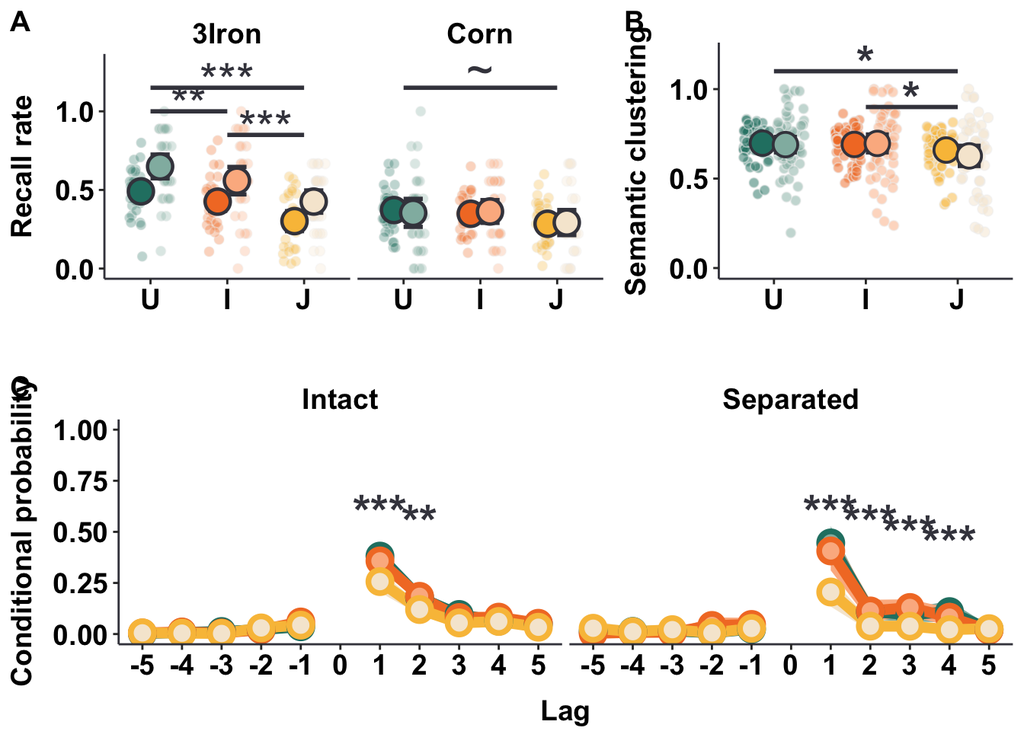

```r
fig3_top <- ggarrange(esKnow1.recallRate_plot, esKnow1.semanticClustering_plot,
                         labels = c("A", "B"),
                         ncol = 2, nrow = 1,
                      widths = c(1.5, 1))
figure3 <- ggarrange(fig3_top, esKnow1_lagCRP_plot,
                     labels = c("", "C"),
                     ncol = 1, nrow = 2)
figure3
```

```r
# setwd('../plots/')
# ggsave("esKnow1_figure3.pdf", plot = figure3, width = 9, height = 8, device = cairo_pdf)
# pdf_convert(pdf = "esKnow1_figure3.pdf", format = "png", dpi = 300,
#             filenames = "esKnow1_figure3.png")
```

## esKnow1 conclusion

Disrupting the flow of information by interrupting or jumbling movie presentation seem to have minimal influence on segmentation. Jumbling movies at 1 minute interval increases button press only at the first 5 seconds interval of a newly presented clip. However, despite relatively intact segmentation behavior, memory for jumbled (and interrupted) conditions seem to be affected. Jumbling movie presentation lowers overall memory for the experience and impairs its organization. Interrupted movie presentation may also have some influence of memory organization, though perhaps minimal (as evidenced from lower +1 lag compared to Uninterrupted but comparable temporal clustering score).

# esKnow2

Minimal influence of disruption in information flow on segmentation performance suggest that segmentation may rely on information localized in time. Would more extreme disruption needed to observe changes in segmentation performance?

**Note on esKnow2 segmentation data** Segmentation data for esKnow2 Uninterrupted coarse segmentation does not seem to be better than random performance. So we’ll use Uninterrupted data from exp 1 to evaluate esKnow2 Interrupted and Jumbled performance

Switch Uninterrupted data of esKnow2.segmentdata with esKnow 1

```r
esKnow2.segmentdata <- esKnow2.segmentdata %>% dplyr::filter(condition != "Uninterrupted")
esKnow2.segmentdata <- rbind(esKnow2.segmentdata, esKnow1.segmentdata[esKnow1.segmentdata$condition == "Uninterrupted" & esKnow1.segmentdata$grainorder == 1,] %>% dplyr::select(subid, condition, grain, movName, clipNo, bpTime.series))
```

**Spectral density** What kind of information may jumbled participants be using for segmentation?

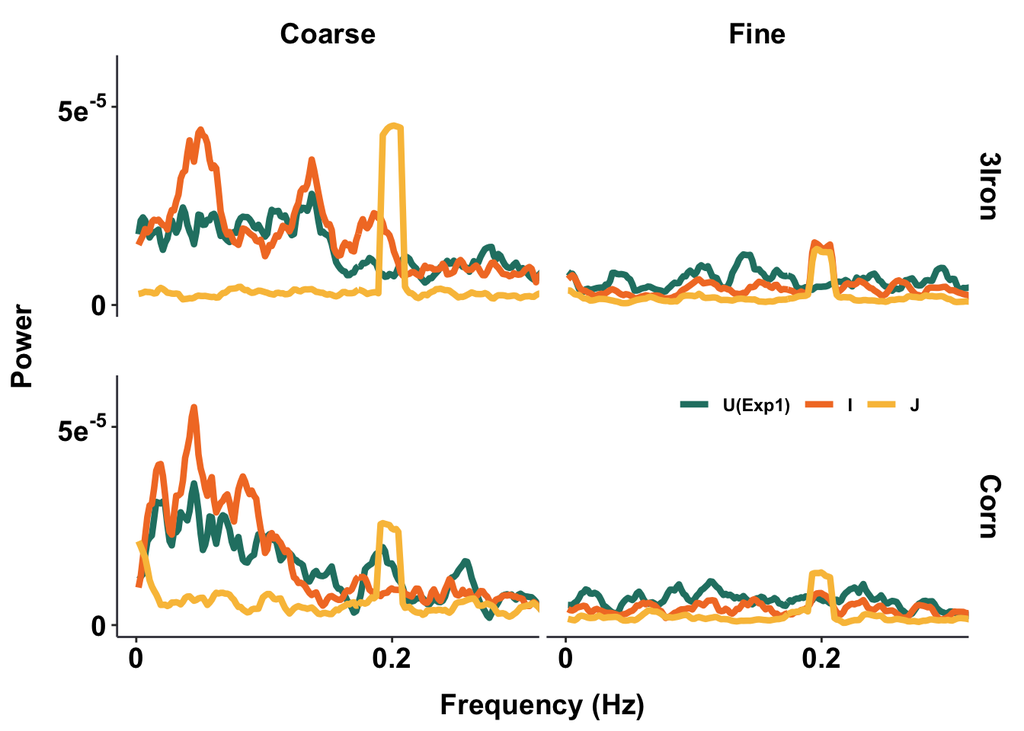

```r
esKnow2.spectral <- data.frame()
esKnow2.spectral.summary <- data.frame()
esKnow2.density.df <- data.frame()

for(cond in unique(esKnow2.segmentdata$condition)){
  for(movie in unique(esKnow2.segmentdata$movName)){
    # if(movie == '3Iron'){
    #   movDur = iron.mov.dur
    # }else{
    #   movDur = corn.mov.dur
    # }
    movDur = 566
    for(segmentGrain in unique(esKnow2.segmentdata$grain)){

      data <- esKnow2.segmentdata[esKnow2.segmentdata$condition == cond&
                                  esKnow2.segmentdata$movName == movie &
                                  esKnow2.segmentdata$grain == segmentGrain,]
      data <- data %>% dplyr::filter(!is.na(bpTime.series)) %>% dplyr::filter(bpTime.series <= movDur)
      data.density <- density(data$bpTime.series, bw = bw, adjust = spect.adj, n = movDur)

      repeat.dens.x <- which(diff(ceiling(data.density$x)) == 0)
      dens.y <- data.density$y
      for (rep in repeat.dens.x){
        dens.y[rep:rep+1] <- mean(dens.y[rep], dens.y[rep+1])
      }
      esKnow2.density.df <- rbind(esKnow2.density.df, data.frame(time = ceiling(data.density$x), density = dens.y, movName = movie, grain = segmentGrain, condition = cond, name = paste(cond,segmentGrain,movie, sep = "_")))

      data.spect <- spectrum(data.density$y, log = "no", span = 10, plot = FALSE)
      data.spx <- data.spect$freq/del
      data.spy <- 2*data.spect$spec
      esKnow2.spectral <- rbind(esKnow2.spectral, data.frame(condition = factor(cond, levels = condition.factor), movName = factor(movie, levels = movie.factor), grain = factor(segmentGrain, levels = grain.factor), spx = data.spx, spy = data.spy))

      esKnow2.spectral.summary <- rbind(esKnow2.spectral.summary, data.frame(condition = factor(cond, levels = condition.factor), movName = factor(movie, levels = movie.factor), grain = factor(segmentGrain, levels = grain.factor), bw_method = bw, bw = data.density$bw))
    }
  }
}

spectral.dens_plot <- ggplot(esKnow2.spectral, aes(x = spx, y = spy, fill = condition, color = condition))+
  #geom_jitter(width = jitter.width, alpha = 0.1, show.legend = FALSE)+
  #geom_line(stat = "summary", fun = "mean", size = .8)+
  stat_summary(fun = mean, geom = "line", size = 1.5, show.legend = TRUE)+
  scale_fill_manual(values = colors$point.colors, labels = c("U(Exp1)", "I", "J"))+
  scale_color_manual(values = colors$point.colors, labels = c("U(Exp1)", "I", "J"))+
  scale_y_continuous(breaks = c(0,.00005), label = c(expression(bold("0")), expression( bold('5e' ^bold("-5")) )))+
  scale_x_continuous(breaks = c(0,0.2), label = c("0", "0.2"))+
  facet_grid(movName~grain, scales = "fixed", labeller = labeller(grain = c("c" = "Coarse", "f" = "Fine"),
                                                                    movName = c("3Iron" = "3Iron", "Corn" = "Corn")))+
  labs(y = "Power", x = "Frequency (Hz)")+
  theme(panel.spacing.y = unit(2, "lines"))+
  theme(axis.title.y = element_text(margin = margin(t = 0, r = 10, b = 0, l = 0)))+
  theme(axis.title.x = element_text(margin = margin(t = 15, r = 0, b = 0, l = 0)))+
  theme(legend.position = c(.8, .4),
        legend.text = element_text(face = txt.face),
        legend.direction = "horizontal")+
  coord_cartesian(xlim = c(0,.3), ylim = c(0,.00006))+
  theme.esKnow +  #theme(legend.text = element_text(size = 14))+
  theme(axis.text.y = element_text(face=txt.face),
          strip.text.y = element_text(face=txt.face))

spectral.dens_plot
```

```r
# setwd('../plots/')
# ggsave("esKnow2_spectral_dens.pdf", plot = spectral.dens_plot, width = 7, height = 6, device = cairo_pdf)
# pdf_convert(pdf = "esKnow2_spectral_dens.pdf", format = "png", dpi = 300,
#             filenames = "esKnow2_spectral_dens.png")

# setwd('../plots/')
# ggsave("esKnow2_spectral_legend.pdf", plot = spectral.dens_plot, width = 7, height = 4, device = cairo_pdf)
# pdf_convert(pdf = "esKnow2_spectral_legend.pdf", format = "png", dpi = 300,
#             filenames = "esKnow2_spectral_legend.png")
```

For jumbled participants, when information cannot be coherently accumulated for long periods of time (beyond 5s), segmentation seem to rely on localized transient signal. This is evident from the strong .2 hertz component (coinciding with the presentation of a new clip) in Jumbled participants’ bp density over time.

**Cluster analysis**

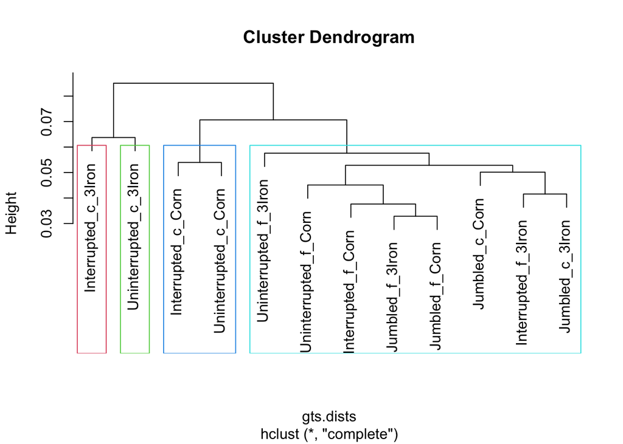

```r
esKnow2.density.df <- esKnow2.density.df %>% distinct()

dens.mat <- esKnow2.density.df %>% filter(time < min(iron.mov.dur, corn.mov.dur)) %>% dplyr::select('time', 'density', 'name') %>% spread(name, density)
dens.mat[is.na(dens.mat)] <- 0
dens.mat <- data.matrix(dens.mat[2:length(dens.mat)])

gts.dists = dist(t(dens.mat))
#fviz_dist(gts.dists, gradient = list(low = "white", mid = "orange", high = "red"))

gts.hclust = hclust(gts.dists, method = "complete")
plot(gts.hclust)
rect.hclust(gts.hclust, k = 4, border = 2:5)
```

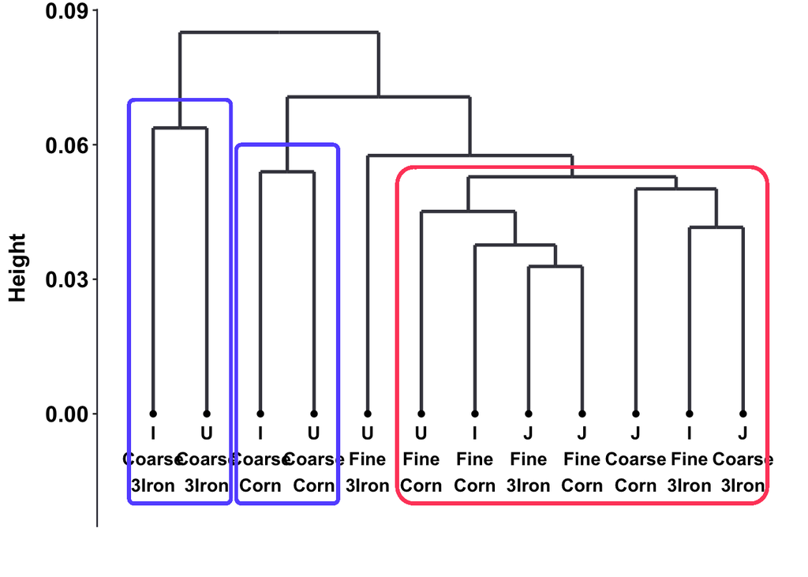

```r
dhc <- as.dendrogram(gts.hclust)
data <- dendro_data(dhc, type = "rectangle")

dendo_labels <- data.frame(x = sort(unique(as.integer(data$segments$x))), y = rep(-0.01, length(unique(as.integer(data$segments$x)))),
                           labels = c('I\nCoarse\n3Iron',
                                      'U\nCoarse\n3Iron',
                                      'I\nCoarse\nCorn',
                                      'U\nCoarse\nCorn',
                                      'U\nFine\n3Iron',
                                      'U\nFine\nCorn',
                                      'I\nFine\nCorn',
                                      'J\nFine\n3Iron',
                                      'J\nFine\nCorn',
                                      'J\nCoarse\nCorn',
                                      'I\nFine\n3Iron',
                                      'J\nCoarse\n3Iron'),
                           endpoint = rep(0, length(unique(as.integer(data$segments$x)))))

esKnow2.segmentCluster.plot <- ggplot(segment(data)) +
  geom_segment(aes(x = x, y = y, xend = xend, yend = yend), size = 1, color = outline.color) +
  geom_point(data = dendo_labels, aes(y = endpoint, x = x), inherit.aes = FALSE)+
  labs(y = "Height", x = "")+
  #scale_y_reverse(expand = c(0.2, 0))+
  theme(axis.line.x = element_blank(),
        axis.text.x = element_blank(),
        axis.ticks.x = element_blank())+
  #expand_limits(y = c(-.01, .08))+
  geom_text(data = dendo_labels, aes(x = x, y = y, label = labels), inherit.aes = FALSE, size = 4, fontface = txt.face)+
  ggchicklet:::geom_rrect(aes(xmin = 0.55, xmax = 2.45, ymin = -0.02, ymax = 0.07), fill = NA, color = "#655aff", r = unit(0.05, 'npc'), size = 1)+
  ggchicklet:::geom_rrect(aes(xmin = 2.55, xmax = 4.45, ymin = -0.02, ymax = 0.06), fill = NA, color = "#655aff", r = unit(0.05, 'npc'), size = 1)+
  # ggchicklet:::geom_rrect(aes(xmin = 5.55, xmax = 9.45, ymin = -0.02, ymax = 0.043), fill = NA, color = "#ff4c69", r = unit(0.05, 'npc'), size = 1)+
  ggchicklet:::geom_rrect(aes(xmin = 5.55, xmax = 12.45, ymin = -0.02, ymax = 0.055), fill = NA, color = "#ff4c69", r = unit(0.05, 'npc'), size = 1)+
  theme.esKnow

esKnow2.segmentCluster.plot
```

```r
#p <- ggdendrogram(dhc)

# setwd('../plots/')
# ggsave("esKnow2_clusterAnalysis.pdf", plot = esKnow2.segmentCluster.plot, width = 10, height = 6, device = cairo_pdf)
# pdf_convert(pdf = "esKnow2_clusterAnalysis.pdf", format = "jpeg", dpi = 300,
#             filenames = "esKnow2_clusterAnalysis.jpg")
```

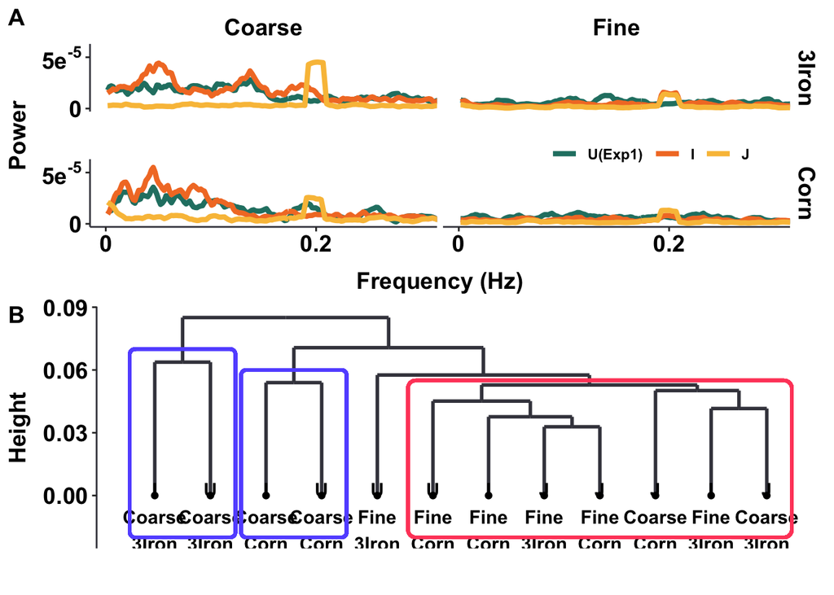

```r
figure5 <- ggarrange(spectral.dens_plot, esKnow2.segmentCluster.plot,
                     nrow = 2, ncol = 1,
                     labels = c("A", "B"))
figure5
```

```r
# setwd('../plots/')
# ggsave("esKnow2_figure5.pdf", plot = figure5, width = 9, height = 10, device = cairo_pdf)
# pdf_convert(pdf = "esKnow2_figure5.pdf", format = "png", dpi = 300,
#             filenames = "esKnow2_figure5.png")
```